# Exploring the Correlation Between Qualifying Performance and Race Results in Formula 1 from 2010 Onward

## 1. Summary

Formula 1, a pinnacle of motorsport, combines technological excellence and athletic prowess, creating a captivating spectacle for fans worldwide. In this project, we aim to dissect the correlation between qualifying performances and race outcomes in Formula 1, leveraging a comprehensive dataset from Kaggle covering the World Championship from 1950 to 2020.

## Objectives

1. **Correlation Exploration:** Investigate the relationship between qualifying positions and final race standings.
2. **Track Variability:** Explore potential variations in qualifying-race correlations across different tracks.
3. **Temporal Trends:** Examine how the correlation dynamics have shifted over the years.
4. **Strategic Impact:** Assess the influence of strategic elements like pit stops on race results.

## Methodology

We will employ statistical and visual techniques to evaluate the strength and direction of the correlation, providing a nuanced analysis of Formula 1 competition dynamics. Merging datasets on qualifying positions, race results, and strategic events will enable us to uncover insights that illuminate the complex interplay between qualifying performances and race outcomes.

## Keywords

Formula 1, Qualifying, Race Results, Correlation Analysis, Track Variability, Temporal Trends

Through this comprehensive analysis, we seek to unravel the intricate relationship between qualifying and race performance, contributing valuable insights to the understanding of Formula 1 dynamics. The results of our study will not only inform motorsport enthusiasts but also provide strategic implications for teams and stakeholders within the Formula 1 ecosystem.

## 2. Ask Phase

# 2.1 Research Questions

The primary objective of this capstone project is to conduct an in-depth analysis of the Formula 1 dataset, focusing on identifying correlations and performing exploratory data analysis (EDA). The key research questions guiding our exploration are as follows:

1. **Correlations Between Qualifying Positions and Final Race Standings:**
   - Explore the relationship between qualifying positions and race outcomes to identify any statistically significant correlations.
2. **Variations Across Different Tracks in the Formula 1 Circuit:**
   - Investigate potential variations in the strength and direction of correlations based on the characteristics of different racing tracks.
3. **Temporal Shifts in Correlation Dynamics Over the Years:**
   - Examine historical trends to identify notable changes in the correlation between qualifying positions and race outcomes over the years.
4. **Impact of Strategic Elements on Final Race Standings:**
   - Analyze the influence of strategic elements, such as pit stops and safety car interventions, on race results and identify correlations between these elements and the final standings.
5. **Exploration of Different Drivers and Teams:**
   - Investigate how different drivers and teams contribute to the overall correlation patterns and explore potential disparities among them.

Through the exploration of these research questions, we aim to unravel the complexities of Formula 1 competition dynamics and shed light on the factors influencing qualifying and race results.

# 3. Prepare Phase

## 3.1 Dataset Used

The Formula 1 World Championship (1950 - 2023) dataset (CC0: Public Domain) will be the cornerstone of this analysis, generously shared on Kaggle by the user Vopani. The dataset is available at the following link: [Formula 1 World Championship (1950 - 2020)](https://www.kaggle.com/datasets/rohanrao/formula-1-world-championship-1950-2020).

## 3.2 Accessibility and Privacy of Data

The data is licensed under CC0: Public Domain, waiving all of his or her rights to the work worldwide under copyright law, including all related and neighboring rights, to the extend by law. The work can be copied, modified, distributed and perform the work, even for commercial purposes, all without asking permission.

## 3.3 Information About Our Dataset

The data is sourced and compiled from [Ergast Motor Racing Data API](http://ergast.com/mrd/).

## 3.4 Data Organization and Verification

The dataset is a collection of 14 .csv files. The datasets consists of wide-ranging information from constructors results, circuits, drivers information, lap times, races results, sprint races results, qualyfing results and drivers standing; Several data frames will not be used for the analysis because of the following reasons:

- They are subsets of larger, more complete data frames.
- They are not interesting for our analysis.

## 3.5 Data Limitations

### 3.5.1 Incomplete Metadata

- **Limitation:** The dataset lacks certain metadata, such as location, weather conditions, and specific contextual details.
- **Impact:** Contextualizing race performance variations attributed to external factors may be challenging.

### 3.5.2 Limited Demographic Information

- **Limitation:** Demographic data, including age, nationality, and other personal details, may not be available or may be incomplete.
- **Impact:** Understanding the diverse characteristics of drivers is crucial, especially in exploring correlations and variations in performance.

### 3.5.3 Variable Data Quality Across Seasons

- **Limitation:** Data quality may vary between seasons due to changes in regulations, technology, and reporting standards.
- **Impact:** Analyzing correlations over time may be influenced by inconsistencies in data recording methods.

### 3.5.4 Event-Specific External Factors

- **Limitation:** External factors, such as weather conditions, track characteristics, and race incidents, may significantly impact race outcomes.
- **Impact:** Isolating the influence of qualifying positions on race results may be challenging without accounting for these external variables.

### 3.5.5 Team Strategy Dynamics

- **Limitation:** The dataset may not comprehensively capture team strategies, including pit stops, tire choices, and strategic decisions during the race.
- **Impact:** Correlating individual driver performance with race outcomes may not reflect the full spectrum of team influence on results.

### 3.5.6 Limited Granularity in Qualifying Data

- **Limitation:** The dataset may lack granular details about specific aspects of qualifying sessions, such as driver errors, technical issues, or incidents during the qualifying laps.
- **Impact:** Understanding the nuances behind qualifying positions may be restricted, limiting the depth of correlation analysis.

Understanding these limitations is crucial for a nuanced interpretation of the analysis and for acknowledging the potential constraints in drawing definitive conclusions.

# 4. Process Phase

Data processing, analysis, and visualization will be conducted using R Programming within R Studio.

## 4.1 Installing Packages and Opening Libraries

For our analysis, we will utilize the following packages:

- ‘tidyverse’
- ‘corrplot’
- ‘lmtest’
- ‘dplyr’
- ‘viridis’
- ‘leaflet’

```r
#libraries
library(tidyverse)
```

```r
library(corrplot)
library(lmtest)
library(dplyr)
library(viridis)
library(leaflet)
```

## 4.2 Importing datasets

The following tables will be used:

```r
#read data
sprint_results_df <- read_csv("C:/Users/cibei/OneDrive/Desktop/Coding_for_data_science/R_folder/R-project/dataset/sprint_results.csv")
seasons_df <- read_csv("C:/Users/cibei/OneDrive/Desktop/Coding_for_data_science/R_folder/R-project/dataset/seasons.csv")
results_df <- read_csv("C:/Users/cibei/OneDrive/Desktop/Coding_for_data_science/R_folder/R-project/dataset/results.csv")
races_df <- read.csv("C:/Users/cibei/OneDrive/Desktop/Coding_for_data_science/R_folder/R-project/dataset/races.csv")
qualifying_df <- read_csv("C:/Users/cibei/OneDrive/Desktop/Coding_for_data_science/R_folder/R-project/dataset/qualifying.csv")
pit_stops_df <- read_csv("C:/Users/cibei/OneDrive/Desktop/Coding_for_data_science/R_folder/R-project/dataset/pit_stops.csv")
lap_times_df <- read_csv("C:/Users/cibei/OneDrive/Desktop/Coding_for_data_science/R_folder/R-project/dataset/lap_times.csv")
circuits_df <- read_csv("C:/Users/cibei/OneDrive/Desktop/Coding_for_data_science/R_folder/R-project/dataset/circuits.csv")
constructors_df <- read_csv("C:/Users/cibei/OneDrive/Desktop/Coding_for_data_science/R_folder/R-project/dataset/constructors.csv")
constructors_results_df <- read_csv("C:/Users/cibei/OneDrive/Desktop/Coding_for_data_science/R_folder/R-project/dataset/constructor_results.csv")
constructors_standing_df <- read_csv("C:/Users/cibei/OneDrive/Desktop/Coding_for_data_science/R_folder/R-project/dataset/constructor_standings.csv")
driver_standings_df <- read_csv("C:/Users/cibei/OneDrive/Desktop/Coding_for_data_science/R_folder/R-project/dataset/driver_standings.csv")
drivers_df <- read_csv("C:/Users/cibei/OneDrive/Desktop/Coding_for_data_science/R_folder/R-project/dataset/drivers.csv")
```

### 4.3 Preview and Inspection of Datasets

Conducting a preliminary preview and concise inspection of the selected data frames to gain insights into their structure and content.

```r
#check data
head(sprint_results_df)
```

| resultId | raceId | driverId | constructorId | number | grid | position | positionText | positionOrder | points | laps | time | milliseconds | fastestLap | fastestLapTime | statusId |
| --- | --- | --- | --- | --- | --- | --- | --- | --- | --- | --- | --- | --- | --- | --- | --- |
| 1 | 1061 | 830 | 9 | 33 | 2 | 1 | 1 | 1 | 3 | 17 | 25:38.426 | 1538426 | 14 | 1:30.013 | 1 |
| 2 | 1061 | 1 | 131 | 44 | 1 | 2 | 2 | 2 | 2 | 17 | +1.430 | 1539856 | 17 | 1:29.937 | 1 |
| 3 | 1061 | 822 | 131 | 77 | 3 | 3 | 3 | 3 | 1 | 17 | +7.502 | 1545928 | 17 | 1:29.958 | 1 |
| 4 | 1061 | 844 | 6 | 16 | 4 | 4 | 4 | 4 | 0 | 17 | +11.278 | 1549704 | 16 | 1:30.163 | 1 |
| 5 | 1061 | 846 | 1 | 4 | 6 | 5 | 5 | 5 | 0 | 17 | +24.111 | 1562537 | 16 | 1:30.566 | 1 |
| 6 | 1061 | 817 | 1 | 3 | 7 | 6 | 6 | 6 | 0 | 17 | +30.959 | 1569385 | 17 | 1:30.640 | 1 |

```r
head(seasons_df)
```

| year | url |
| --- | --- |
| 2009 | http://en.wikipedia.org/wiki/2009_Formula_One_season |
| 2008 | http://en.wikipedia.org/wiki/2008_Formula_One_season |
| 2007 | http://en.wikipedia.org/wiki/2007_Formula_One_season |
| 2006 | http://en.wikipedia.org/wiki/2006_Formula_One_season |
| 2005 | http://en.wikipedia.org/wiki/2005_Formula_One_season |
| 2004 | http://en.wikipedia.org/wiki/2004_Formula_One_season |

```r
head(results_df)
```

| resultId | raceId | driverId | constructorId | number | grid | position | positionText | positionOrder | points | laps | time | milliseconds | fastestLap | rank | fastestLapTime | fastestLapSpeed | statusId |
| --- | --- | --- | --- | --- | --- | --- | --- | --- | --- | --- | --- | --- | --- | --- | --- | --- | --- |
| 1 | 18 | 1 | 1 | 22 | 1 | 1 | 1 | 1 | 10 | 58 | 1:34:50.616 | 5690616 | 39 | 2 | 1:27.452 | 218.300 | 1 |
| 2 | 18 | 2 | 2 | 3 | 5 | 2 | 2 | 2 | 8 | 58 | +5.478 | 5696094 | 41 | 3 | 1:27.739 | 217.586 | 1 |
| 3 | 18 | 3 | 3 | 7 | 7 | 3 | 3 | 3 | 6 | 58 | +8.163 | 5698779 | 41 | 5 | 1:28.090 | 216.719 | 1 |
| 4 | 18 | 4 | 4 | 5 | 11 | 4 | 4 | 4 | 5 | 58 | +17.181 | 5707797 | 58 | 7 | 1:28.603 | 215.464 | 1 |
| 5 | 18 | 5 | 1 | 23 | 3 | 5 | 5 | 5 | 4 | 58 | +18.014 | 5708630 | 43 | 1 | 1:27.418 | 218.385 | 1 |
| 6 | 18 | 6 | 3 | 8 | 13 | 6 | 6 | 6 | 3 | 57 | \\N | \\N | 50 | 14 | 1:29.639 | 212.974 | 11 |

```r
head(races_df)
```

|  | raceId | year | round | circuitId | name | date | time | url | fp1_date | fp1_time | fp2_date | fp2_time | fp3_date | fp3_time | quali_date | quali_time | sprint_date | sprint_time |
| --- | --- | --- | --- | --- | --- | --- | --- | --- | --- | --- | --- | --- | --- | --- | --- | --- | --- | --- |
| 1 | 1 | 2009 | 1 | 1 | Australian Grand Prix | 2009-03-29 | 06:00:00 | http://en.wikipedia.org/wiki/2009_Australian_Grand_Prix | \\N | \\N | \\N | \\N | \\N | \\N | \\N | \\N | \\N | \\N |
| 2 | 2 | 2009 | 2 | 2 | Malaysian Grand Prix | 2009-04-05 | 09:00:00 | http://en.wikipedia.org/wiki/2009_Malaysian_Grand_Prix | \\N | \\N | \\N | \\N | \\N | \\N | \\N | \\N | \\N | \\N |
| 3 | 3 | 2009 | 3 | 17 | Chinese Grand Prix | 2009-04-19 | 07:00:00 | http://en.wikipedia.org/wiki/2009_Chinese_Grand_Prix | \\N | \\N | \\N | \\N | \\N | \\N | \\N | \\N | \\N | \\N |
| 4 | 4 | 2009 | 4 | 3 | Bahrain Grand Prix | 2009-04-26 | 12:00:00 | http://en.wikipedia.org/wiki/2009_Bahrain_Grand_Prix | \\N | \\N | \\N | \\N | \\N | \\N | \\N | \\N | \\N | \\N |
| 5 | 5 | 2009 | 5 | 4 | Spanish Grand Prix | 2009-05-10 | 12:00:00 | http://en.wikipedia.org/wiki/2009_Spanish_Grand_Prix | \\N | \\N | \\N | \\N | \\N | \\N | \\N | \\N | \\N | \\N |
| 6 | 6 | 2009 | 6 | 6 | Monaco Grand Prix | 2009-05-24 | 12:00:00 | http://en.wikipedia.org/wiki/2009_Monaco_Grand_Prix | \\N | \\N | \\N | \\N | \\N | \\N | \\N | \\N | \\N | \\N |

```r
head(qualifying_df)
```

| qualifyId | raceId | driverId | constructorId | number | position | q1 | q2 | q3 |
| --- | --- | --- | --- | --- | --- | --- | --- | --- |
| 1 | 18 | 1 | 1 | 22 | 1 | 1:26.572 | 1:25.187 | 1:26.714 |
| 2 | 18 | 9 | 2 | 4 | 2 | 1:26.103 | 1:25.315 | 1:26.869 |
| 3 | 18 | 5 | 1 | 23 | 3 | 1:25.664 | 1:25.452 | 1:27.079 |
| 4 | 18 | 13 | 6 | 2 | 4 | 1:25.994 | 1:25.691 | 1:27.178 |
| 5 | 18 | 2 | 2 | 3 | 5 | 1:25.960 | 1:25.518 | 1:27.236 |
| 6 | 18 | 15 | 7 | 11 | 6 | 1:26.427 | 1:26.101 | 1:28.527 |

```r
head(pit_stops_df)
```

| raceId | driverId | stop | lap | time | duration | milliseconds |
| --- | --- | --- | --- | --- | --- | --- |
| 841 | 153 | 1 | 1 | 17:05:23 | 26.898 | 26898 |
| 841 | 30 | 1 | 1 | 17:05:52 | 25.021 | 25021 |
| 841 | 17 | 1 | 11 | 17:20:48 | 23.426 | 23426 |
| 841 | 4 | 1 | 12 | 17:22:34 | 23.251 | 23251 |
| 841 | 13 | 1 | 13 | 17:24:10 | 23.842 | 23842 |
| 841 | 22 | 1 | 13 | 17:24:29 | 23.643 | 23643 |

```r
head(lap_times_df)
```

| raceId | driverId | lap | position | time | milliseconds |
| --- | --- | --- | --- | --- | --- |
| 841 | 20 | 1 | 1 | 01:38:00 | 98109 |
| 841 | 20 | 2 | 1 | 01:33:00 | 93006 |
| 841 | 20 | 3 | 1 | 01:32:00 | 92713 |
| 841 | 20 | 4 | 1 | 01:32:00 | 92803 |
| 841 | 20 | 5 | 1 | 01:32:00 | 92342 |
| 841 | 20 | 6 | 1 | 01:32:00 | 92605 |

```r
head(circuits_df)
```

| circuitId | circuitRef | name | location | country | lat | lng | alt | url |
| --- | --- | --- | --- | --- | --- | --- | --- | --- |
| 1 | albert_park | Albert Park Grand Prix Circuit | Melbourne | Australia | -37.84970 | 144.96800 | 10 | http://en.wikipedia.org/wiki/Melbourne_Grand_Prix_Circuit |
| 2 | sepang | Sepang International Circuit | Kuala Lumpur | Malaysia | 2.76083 | 101.73800 | 18 | http://en.wikipedia.org/wiki/Sepang_International_Circuit |
| 3 | bahrain | Bahrain International Circuit | Sakhir | Bahrain | 26.03250 | 50.51060 | 7 | http://en.wikipedia.org/wiki/Bahrain_International_Circuit |
| 4 | catalunya | Circuit de Barcelona-Catalunya | Montmeló | Spain | 41.57000 | 2.26111 | 109 | http://en.wikipedia.org/wiki/Circuit_de_Barcelona-Catalunya |
| 5 | istanbul | Istanbul Park | Istanbul | Turkey | 40.95170 | 29.40500 | 130 | http://en.wikipedia.org/wiki/Istanbul_Park |
| 6 | monaco | Circuit de Monaco | Monte-Carlo | Monaco | 43.73470 | 7.42056 | 7 | http://en.wikipedia.org/wiki/Circuit_de_Monaco |

```r
head(constructors_df)
```

| constructorId | constructorRef | name | nationality | url |
| --- | --- | --- | --- | --- |
| 1 | mclaren | McLaren | British | http://en.wikipedia.org/wiki/McLaren |
| 2 | bmw_sauber | BMW Sauber | German | http://en.wikipedia.org/wiki/BMW_Sauber |
| 3 | williams | Williams | British | http://en.wikipedia.org/wiki/Williams_Grand_Prix_Engineering |
| 4 | renault | Renault | French | http://en.wikipedia.org/wiki/Renault_in_Formula_One |
| 5 | toro_rosso | Toro Rosso | Italian | http://en.wikipedia.org/wiki/Scuderia_Toro_Rosso |
| 6 | ferrari | Ferrari | Italian | http://en.wikipedia.org/wiki/Scuderia_Ferrari |

```r
head(constructors_results_df)
```

| constructorResultsId | raceId | constructorId | points | status |
| --- | --- | --- | --- | --- |
| 1 | 18 | 1 | 14 | \\N |
| 2 | 18 | 2 | 8 | \\N |
| 3 | 18 | 3 | 9 | \\N |
| 4 | 18 | 4 | 5 | \\N |
| 5 | 18 | 5 | 2 | \\N |
| 6 | 18 | 6 | 1 | \\N |

```r
head(constructors_standing_df)
```

| constructorStandingsId | raceId | constructorId | points | position | positionText | wins |
| --- | --- | --- | --- | --- | --- | --- |
| 1 | 18 | 1 | 14 | 1 | 1 | 1 |
| 2 | 18 | 2 | 8 | 3 | 3 | 0 |
| 3 | 18 | 3 | 9 | 2 | 2 | 0 |
| 4 | 18 | 4 | 5 | 4 | 4 | 0 |
| 5 | 18 | 5 | 2 | 5 | 5 | 0 |
| 6 | 18 | 6 | 1 | 6 | 6 | 0 |

```r
head(driver_standings_df)
```

| driverStandingsId | raceId | driverId | points | position | positionText | wins |
| --- | --- | --- | --- | --- | --- | --- |
| 1 | 18 | 1 | 10 | 1 | 1 | 1 |
| 2 | 18 | 2 | 8 | 2 | 2 | 0 |
| 3 | 18 | 3 | 6 | 3 | 3 | 0 |
| 4 | 18 | 4 | 5 | 4 | 4 | 0 |
| 5 | 18 | 5 | 4 | 5 | 5 | 0 |
| 6 | 18 | 6 | 3 | 6 | 6 | 0 |

```r
head(drivers_df)
```

| driverId | driverRef | number | code | forename | surname | dob | nationality | url |
| --- | --- | --- | --- | --- | --- | --- | --- | --- |
| 1 | hamilton | 44 | HAM | Lewis | Hamilton | 1985-01-07 | British | http://en.wikipedia.org/wiki/Lewis_Hamilton |
| 2 | heidfeld | \\N | HEI | Nick | Heidfeld | 1977-05-10 | German | http://en.wikipedia.org/wiki/Nick_Heidfeld |
| 3 | rosberg | 6 | ROS | Nico | Rosberg | 1985-06-27 | German | http://en.wikipedia.org/wiki/Nico_Rosberg |
| 4 | alonso | 14 | ALO | Fernando | Alonso | 1981-07-29 | Spanish | http://en.wikipedia.org/wiki/Fernando_Alonso |
| 5 | kovalainen | \\N | KOV | Heikki | Kovalainen | 1981-10-19 | Finnish | http://en.wikipedia.org/wiki/Heikki_Kovalainen |
| 6 | nakajima | \\N | NAK | Kazuki | Nakajima | 1985-01-11 | Japanese | http://en.wikipedia.org/wiki/Kazuki_Nakajima |

```r
# summary of the data
summary(sprint_results_df)
```

```
##     resultId          raceId        driverId     constructorId
##  Min.   :  1.00   Min.   :1061   Min.   :  1.0   Min.   :  1.0
##  1st Qu.: 45.75   1st Qu.:1071   1st Qu.:817.0   1st Qu.:  6.0
##  Median : 90.50   Median :1084   Median :840.0   Median : 84.0
##  Mean   : 90.50   Mean   :1086   Mean   :714.1   Mean   : 95.5
##  3rd Qu.:135.25   3rd Qu.:1101   3rd Qu.:847.0   3rd Qu.:210.0
##  Max.   :180.00   Max.   :1110   Max.   :858.0   Max.   :214.0
##      number           grid        position         positionText
##  Min.   : 1.00   Min.   : 0.0   Length:180         Length:180
##  1st Qu.:10.00   1st Qu.: 5.0   Class :character   Class :character
##  Median :20.00   Median :10.0   Mode  :character   Mode  :character
##  Mean   :27.55   Mean   :10.1
##  3rd Qu.:44.00   3rd Qu.:15.0
##  Max.   :99.00   Max.   :20.0
##  positionOrder       points         laps           time
##  Min.   : 1.00   Min.   :0.0   Min.   : 0.00   Length:180
##  1st Qu.: 5.75   1st Qu.:0.0   1st Qu.:17.00   Class :character
##  Median :10.50   Median :0.0   Median :21.00   Mode  :character
##  Mean   :10.50   Mean   :1.3   Mean   :19.22
##  3rd Qu.:15.25   3rd Qu.:2.0   3rd Qu.:24.00
##  Max.   :20.00   Max.   :8.0   Max.   :24.00
##  milliseconds        fastestLap        fastestLapTime        statusId
##  Length:180         Length:180         Length:180         Min.   :  1.000
##  Class :character   Class :character   Class :character   1st Qu.:  1.000
##  Mode  :character   Mode  :character   Mode  :character   Median :  1.000
##                                                           Mean   :  3.983
##                                                           3rd Qu.:  1.000
##                                                           Max.   :130.000
```

```r
summary(results_df)
```

```
##     resultId         raceId          driverId     constructorId
##  Min.   :    1   Min.   :   1.0   Min.   :  1.0   Min.   :  1.00
##  1st Qu.: 6521   1st Qu.: 294.8   1st Qu.: 57.0   1st Qu.:  6.00
##  Median :13040   Median : 519.0   Median :163.0   Median : 25.00
##  Mean   :13041   Mean   : 536.7   Mean   :266.3   Mean   : 49.06
##  3rd Qu.:19560   3rd Qu.: 791.0   3rd Qu.:364.0   3rd Qu.: 58.25
##  Max.   :26085   Max.   :1110.0   Max.   :858.0   Max.   :214.00
##
##      number            grid         position         positionText
##  Min.   :  0.00   Min.   : 0.00   Length:26080       Length:26080
##  1st Qu.:  7.00   1st Qu.: 5.00   Class :character   Class :character
##  Median : 16.00   Median :11.00   Mode  :character   Mode  :character
##  Mean   : 17.88   Mean   :11.17
##  3rd Qu.: 24.00   3rd Qu.:17.00
##  Max.   :208.00   Max.   :34.00
##  NA's   :6
##  positionOrder       points            laps            time
##  Min.   : 1.00   Min.   : 0.000   Min.   :  0.00   Length:26080
##  1st Qu.: 6.00   1st Qu.: 0.000   1st Qu.: 22.00   Class :character
##  Median :12.00   Median : 0.000   Median : 53.00   Mode  :character
##  Mean   :12.85   Mean   : 1.907   Mean   : 46.08
##  3rd Qu.:18.00   3rd Qu.: 2.000   3rd Qu.: 66.00
##  Max.   :39.00   Max.   :50.000   Max.   :200.00
##
##  milliseconds        fastestLap            rank           fastestLapTime
##  Length:26080       Length:26080       Length:26080       Length:26080
##  Class :character   Class :character   Class :character   Class :character
##  Mode  :character   Mode  :character   Mode  :character   Mode  :character
##
##
##
##
##  fastestLapSpeed       statusId
##  Length:26080       Min.   :  1.00
##  Class :character   1st Qu.:  1.00
##  Mode  :character   Median : 10.00
##                     Mean   : 17.48
##                     3rd Qu.: 14.00
##                     Max.   :141.00
##
```

```r
summary(races_df)
```

```
##      raceId            year          round          circuitId
##  Min.   :   1.0   Min.   :1950   Min.   : 1.000   Min.   : 1.0
##  1st Qu.: 276.0   1st Qu.:1976   1st Qu.: 4.000   1st Qu.: 9.0
##  Median : 551.0   Median :1994   Median : 8.000   Median :18.0
##  Mean   : 553.4   Mean   :1992   Mean   : 8.494   Mean   :23.7
##  3rd Qu.: 826.0   3rd Qu.:2010   3rd Qu.:12.000   3rd Qu.:34.0
##  Max.   :1120.0   Max.   :2023   Max.   :22.000   Max.   :80.0
##      name               date               time               url
##  Length:1101        Length:1101        Length:1101        Length:1101
##  Class :character   Class :character   Class :character   Class :character
##  Mode  :character   Mode  :character   Mode  :character   Mode  :character
##
##
##
##    fp1_date           fp1_time           fp2_date           fp2_time
##  Length:1101        Length:1101        Length:1101        Length:1101
##  Class :character   Class :character   Class :character   Class :character
##  Mode  :character   Mode  :character   Mode  :character   Mode  :character
##
##
##
##    fp3_date           fp3_time          quali_date         quali_time
##  Length:1101        Length:1101        Length:1101        Length:1101
##  Class :character   Class :character   Class :character   Class :character
##  Mode  :character   Mode  :character   Mode  :character   Mode  :character
##
##
##
##  sprint_date        sprint_time
##  Length:1101        Length:1101
##  Class :character   Class :character
##  Mode  :character   Mode  :character
##
##
##
```

```r
summary(qualifying_df)
```

```
##    qualifyId        raceId          driverId     constructorId
##  Min.   :   1   Min.   :   1.0   Min.   :  1.0   Min.   :  1.00
##  1st Qu.:2456   1st Qu.: 119.5   1st Qu.: 16.0   1st Qu.:  4.00
##  Median :4910   Median : 856.0   Median : 50.0   Median :  9.00
##  Mean   :4920   Mean   : 589.8   Mean   :314.5   Mean   : 44.78
##  3rd Qu.:7384   3rd Qu.: 981.0   3rd Qu.:818.0   3rd Qu.: 28.00
##  Max.   :9872   Max.   :1110.0   Max.   :858.0   Max.   :214.00
##      number         position          q1                 q2
##  Min.   : 0.00   Min.   : 1.00   Length:9815        Length:9815
##  1st Qu.: 7.00   1st Qu.: 6.00   Class :character   Class :character
##  Median :14.00   Median :11.00   Mode  :character   Mode  :character
##  Mean   :18.11   Mean   :11.24
##  3rd Qu.:22.00   3rd Qu.:17.00
##  Max.   :99.00   Max.   :28.00
##       q3
##  Length:9815
##  Class :character
##  Mode  :character
##
##
##
```

```r
summary(pit_stops_df)
```

```
##      raceId          driverId        stop           lap
##  Min.   : 841.0   Min.   :  1   Min.   :1.00   Min.   : 1.00
##  1st Qu.: 888.0   1st Qu.: 18   1st Qu.:1.00   1st Qu.:13.00
##  Median : 958.0   Median :815   Median :2.00   Median :25.00
##  Mean   : 962.8   Mean   :524   Mean   :1.76   Mean   :25.31
##  3rd Qu.:1035.0   3rd Qu.:831   3rd Qu.:2.00   3rd Qu.:36.00
##  Max.   :1110.0   Max.   :858   Max.   :6.00   Max.   :78.00
##      time            duration          milliseconds
##  Length:10089      Length:10089       Min.   :  12897
##  Class1:hms        Class :character   1st Qu.:  21914
##  Class2:difftime   Mode  :character   Median :  23570
##  Mode  :numeric                       Mean   :  75349
##                                       3rd Qu.:  26202
##                                       Max.   :3069017
```

```r
summary(lap_times_df)
```

```
##      raceId          driverId          lap           position
##  Min.   :   1.0   Min.   :  1.0   Min.   : 1.00   Min.   : 1.000
##  1st Qu.: 131.0   1st Qu.: 15.0   1st Qu.:14.00   1st Qu.: 5.000
##  Median : 846.0   Median : 39.0   Median :29.00   Median : 9.000
##  Mean   : 564.9   Mean   :296.9   Mean   :29.99   Mean   : 9.659
##  3rd Qu.: 976.0   3rd Qu.:817.0   3rd Qu.:44.00   3rd Qu.:14.000
##  Max.   :1110.0   Max.   :858.0   Max.   :87.00   Max.   :24.000
##      time           milliseconds
##  Length:551742     Min.   :  55404
##  Class1:hms        1st Qu.:  81993
##  Class2:difftime   Median :  90673
##  Mode  :numeric    Mean   :  95706
##                    3rd Qu.: 102243
##                    Max.   :7507547
```

```r
summary(circuits_df)
```

```
##    circuitId      circuitRef            name             location
##  Min.   : 1.00   Length:77          Length:77          Length:77
##  1st Qu.:20.00   Class :character   Class :character   Class :character
##  Median :40.00   Mode  :character   Mode  :character   Mode  :character
##  Mean   :39.88
##  3rd Qu.:59.00
##  Max.   :80.00
##    country               lat              lng               alt
##  Length:77          Min.   :-37.85   Min.   :-118.189   Length:77
##  Class :character   1st Qu.: 32.78   1st Qu.:  -9.394   Class :character
##  Mode  :character   Median : 40.95   Median :   3.931   Mode  :character
##                     Mean   : 33.44   Mean   :   1.077
##                     3rd Qu.: 46.96   3rd Qu.:  19.249
##                     Max.   : 57.27   Max.   : 144.968
##      url
##  Length:77
##  Class :character
##  Mode  :character
##
##
##
```

### 4.4 Cleaning and formatting datasets

#### 4.4.1 Checking for missing values

We want to be sure that are not missing values.

```r
# Check for missing values
sapply(list(sprint_results_df, seasons_df, results_df, races_df,
            qualifying_df, pit_stops_df, lap_times_df, circuits_df),
       function(x) sum(is.na(x)))
```

```
## [1]   0   0   6   0 499   0   0   0
```

```r
# Find rows with NaN values in 'qualifying_df'
rows_with_na <- which(is.na(qualifying_df), arr.ind = TRUE)

# Display rows with NaN values
if (length(rows_with_na) > 0) {
  print(results_df[rows_with_na[, 1], ], n= 10)
} else {
  cat("No NaN values found in 'qualyfing_df'.\n")
}
```

```
## # A tibble: 499 × 18
##    resultId raceId driverId constructorId number  grid position positionText
##       <dbl>  <dbl>    <dbl>         <dbl>  <dbl> <dbl> <chr>    <chr>
##  1     7402    332      145            22     19     8 "8"      8
##  2     7616      4       15             7      9     1 "3"      3
##  3     7633      4        6             3     17    12 "\\N"    R
##  4     7654      6       18            23     22     1 "1"      1
##  5     8013    359      156            25      3    14 "\\N"    R
##  6     8014    359      122            37     16     4 "\\N"    R
##  7     8154    363      123             3      5     7 "10"     10
##  8     8234    365      156            25      3    19 "13"     13
##  9     3881    201       21            22      5     8 "7"      7
## 10     3882    201       56             6      4     6 "8"      8
## # ℹ 489 more rows
## # ℹ 10 more variables: positionOrder <dbl>, points <dbl>, laps <dbl>,
## #   time <chr>, milliseconds <chr>, fastestLap <chr>, rank <chr>,
## #   fastestLapTime <chr>, fastestLapSpeed <chr>, statusId <dbl>
```

```r
# Find rows with NaN values in 'results_df'
rows_with_na_result_df <- which(is.na(results_df), arr.ind = TRUE)

# Display rows with NaN values
if (length(rows_with_na_result_df) > 0) {
  print(results_df[rows_with_na_result_df[, 1], ], n= length(rows_with_na_result_df))
} else {
  cat("No NaN values found in 'results_df'.\n")
}
```

```
## # A tibble: 6 × 18
##   resultId raceId driverId constructorId number  grid position positionText
##      <dbl>  <dbl>    <dbl>         <dbl>  <dbl> <dbl> <chr>    <chr>
## 1    17716    732      459            66     NA     0 "\\N"    W
## 2    17717    732      462            95     NA     0 "\\N"    W
## 3    17718    732      446           172     NA     0 "\\N"    W
## 4    17719    732      437           170     NA     0 "\\N"    W
## 5    17940    741      485           172     NA     0 "\\N"    W
## 6    20322    728      305            26     NA     0 "\\N"    W
## # ℹ 10 more variables: positionOrder <dbl>, points <dbl>, laps <dbl>,
## #   time <chr>, milliseconds <chr>, fastestLap <chr>, rank <chr>,
## #   fastestLapTime <chr>, fastestLapSpeed <chr>, statusId <dbl>
```

In the qualifying_df, NaN values are present in columns that are not pertinent to our analysis. These irrelevant NaNs will be removed in the subsequent code.

For the results_df, certain columns contain NaN values that are crucial for our analysis. We will strategically address and handle these NaNs when utilizing the data frame to ensure the integrity of our analysis.

#### 4.4.2 Selecting only the interested columns

Cleaning the selected data frames. We will remove columns that are not relevant to our analysis.

```r
#clean data
sprint_results_df <- sprint_results_df %>%
  select(-number, -position, -positionText, -points, -laps, -time, -milliseconds, -fastestLap)

results_df <- results_df %>%
  select(-number,-position, -positionText, -laps, -time, -milliseconds, -fastestLap, -rank)
circuits_df <- circuits_df %>%
  select(-url)

qualifying_df <- qualifying_df %>%
  select(-number, -q1, -q2, -q3)

races_df <- races_df %>%
  select(raceId, year, round, circuitId, name)
```

#### 4.4.3 Duplicates

We will now look for any duplicates:

```r
# Check for duplicates in each data frame
for (df in list(sprint_results_df, seasons_df, results_df, races_df,
                qualifying_df, pit_stops_df, lap_times_df, circuits_df,
                drivers_df, constructors_df, constructors_results_df,
                driver_standings_df, constructors_standing_df)) {
  duplicate_rows <- df[duplicated(df), ]

  # Print the duplicate rows if any
  if (nrow(duplicate_rows) > 0) {
    cat("Duplicate rows in", deparse(substitute(df)), ":\n")
    print(duplicate_rows)
  } else {
    cat("No duplicate rows found in", deparse(substitute(df)), ".\n")
  }
}
```

```
## No duplicate rows found in df .
## No duplicate rows found in df .
## No duplicate rows found in df .
## No duplicate rows found in df .
## No duplicate rows found in df .
## No duplicate rows found in df .
## No duplicate rows found in df .
## No duplicate rows found in df .
## No duplicate rows found in df .
## No duplicate rows found in df .
## No duplicate rows found in df .
## No duplicate rows found in df .
## No duplicate rows found in df .
```

#### 4.4.4 Check Consistency Between Qualifying Position and Grid Position

We aim to verify the consistency between the qualifying position and grid position for each raceId and driverId combination. Ideally, these positions should differ due to the possibility of penalizations affecting the grid.

```r
# Check if position and grid have the same data for each raceId and driverId
matching_positions <- qualifying_df %>%
  inner_join(results_df, by = c("raceId", "driverId")) %>%
  filter(position != grid) %>%  # filter where position in qualifying is different from grid in results
  select(raceId, driverId, position, grid)

# Display the result
if (nrow(matching_positions) > 0) {
  cat("Rows where position and grid are different for the same raceId and driverId:\n")
  print(matching_positions)
} else {
  cat("Position and grid are the same for all rows with matching raceId and driverId.\n")
}
```

```
## Rows where position and grid are different for the same raceId and driverId:
## # A tibble: 2,337 × 4
##    raceId driverId position  grid
##     <dbl>    <dbl>    <dbl> <dbl>
##  1     18       10        9    18
##  2     18       20       10     9
##  3     18       22       11    10
##  4     18        4       12    11
##  5     18       18       13    12
##  6     18        6       14    13
##  7     18       17       15    14
##  8     18        8       16    15
##  9     18       21       17    16
## 10     18        7       18    17
## # ℹ 2,327 more rows
```

#### 4.5 Filtering and Merging Datasets

To focus our analysis, we will narrow down the dataset to include only records from the year 2010 onwards. Subsequently, we will perform a merge operation on the ‘races’ and ‘results’ datasets, utilizing the ‘raceId’ as the key. This step is crucial for consolidating relevant information and preparing the data for further in-depth analysis.

```r
# Filter races for the season 2010 and later
races_data <- races_df %>%
  filter(year >= 2010)

# Filter and clean results data for the selected races
merged_data <- results_df %>%
  inner_join(races_data, by = "raceId") %>%
  filter(!is.na(grid) & !is.na(positionOrder))  # Remove rows with missing values

sprint_merged_data <- sprint_results_df %>%
  inner_join(races_data, by = "raceId") %>%
  filter(!is.na(grid) & !is.na(positionOrder))  # Remove rows with missing values
```

## 5. Exploratory and Correlation Data Analysis

In this chapter, we embark on a journey of Exploratory and Correlation Data Analysis to unravel the intricate patterns, correlations, and trends residing within the Formula 1 data frames. This analysis serves as a crucial prelude to in-depth statistical analyses, offering a comprehensive understanding of the data’s structure and characteristics.

### Objectives:

1. **Uncover Patterns and Trends:**
   - It enables us to identify inherent patterns, both visually and statistically, shedding light on potential relationships among variables.
2. **Validate Assumptions:**
   - Through graphical representations and summary statistics, we validate assumptions made during the earlier stages of data processing.
3. **Identify Outliers and Anomalies:**
   - Robust visualizations and descriptive statistics aid in the identification of outliers or anomalies that may impact subsequent analyses.
4. **Understand Data Distribution:**
   - bar plots and scatter plots offer insights into the distribution of key variables, guiding our understanding of the dataset’s characteristics.
5. **Correlation Exploration:**
   - Visualizing correlations among variables helps uncover potential dependencies, steering us towards more targeted analyses.

### Methodology:

1. **Graphical Representations:**
   - Utilizing ggplot2 and other visualization libraries, we generate a spectrum of plots, including scatter plots and bar plots, to capture diverse aspects of the data.
2. **Statistical Summary:**
   - Descriptive statistics and summary metrics provide a quantitative snapshot of key variables, aiding in the identification of central tendencies and dispersions.
3. **Temporal Trends:**
   - Time series visualizations and analyses unveil temporal trends, allowing us to discern any shifting patterns in Formula 1 dynamics over the years.

### Key Takeaways:

- It serves as a crucial step in understanding the inherent nature of the data before delving into complex statistical models.
- Visualizations and statistical summaries act as powerful tools in elucidating patterns and guiding subsequent analyses.
- Identification of outliers and anomalies ensures a robust foundation for further exploration and hypothesis testing.

As we embark on this journey, the objective is to glean meaningful insights that will inform subsequent analyses and contribute to a holistic understanding of the Formula 1 competition dynamics.

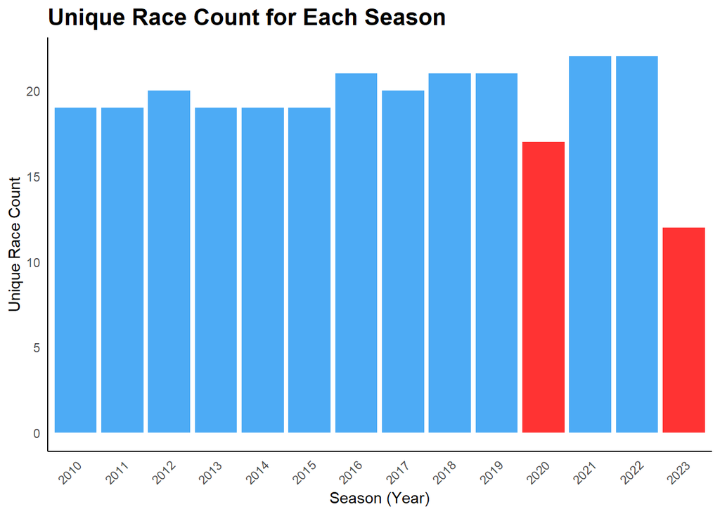

```r
# Count the number of unique raceId entries for each year
unique_race_count <- merged_data %>%
  group_by(year) %>%
  summarise(unique_race_count = n_distinct(raceId))

# Identify exceptional years
exceptional_years <- c(2020, 2023)

# Plot the results
ggplot(unique_race_count, aes(x = factor(year), y = unique_race_count, fill = factor(year))) +
  geom_bar(stat = "identity", alpha = 0.8) +
  scale_fill_manual(values = ifelse(unique_race_count$year %in% exceptional_years, "red", "#2196F3")) +
  labs(title = "Unique Race Count for Each Season",
       x = "Season (Year)",
       y = "Unique Race Count") +
  theme_minimal() +
  theme(axis.text.x = element_text(angle = 45, hjust = 1),
        plot.title = element_text(size = 16, face = "bold"),
        plot.caption = element_text(size = 10),
        panel.grid.major = element_blank(),
        panel.grid.minor = element_blank(),
        panel.border = element_blank(),
        axis.line = element_line(color = "black", size = 0.5),
        legend.position = "none")
```

This code generates a bar plot showing the unique race count for each season (year). The blue bars represent the regular distribution of races, while the red points highlight exceptional years. These exceptional years, such as 2020 and 2023, may have deviated from the usual distribution due to external factors like the COVID-19 pandemic or data update delays.

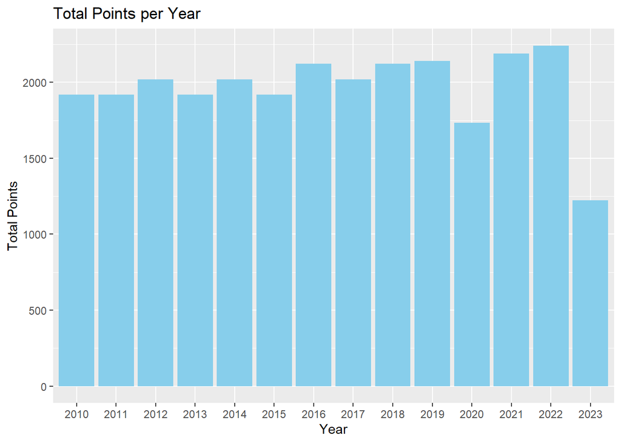

```r
# Sum the points for each year
sum_points <- merged_data %>%
  group_by(year) %>%
  summarize(total_points = sum(across("points", ~ sum(., na.rm = TRUE)), na.rm = TRUE))

# Create a bar plot with the sum of points for each year
ggplot(sum_points, aes(x = as.factor(year), y = total_points)) +
  geom_col(fill = "skyblue") +
  labs(title = "Total Points per Year",
       x = "Year",
       y = "Total Points")
```

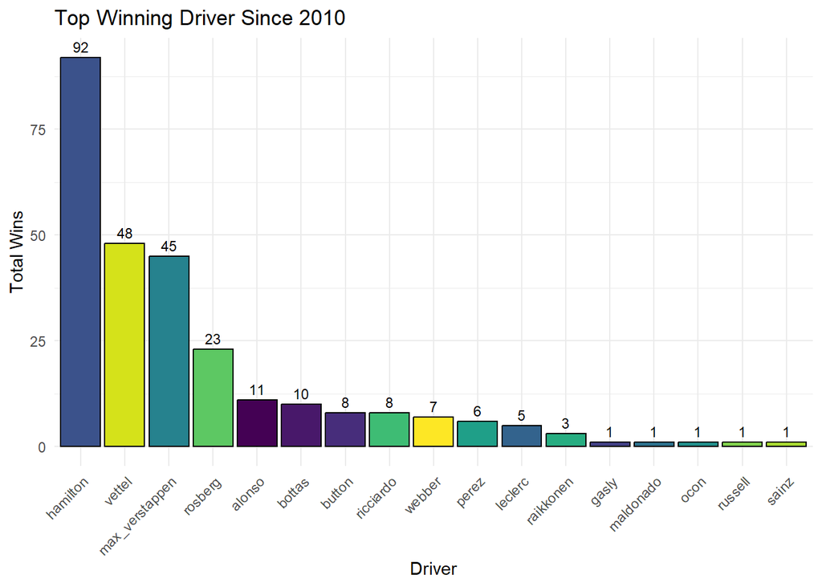

```r
# Summarize total wins for each driver
top_winning_drivers <- merged_data %>%
  filter(positionOrder == 1) %>%
  group_by(driverId) %>%
  summarize(total_wins = n())

# Merge with driver information
top_winning_drivers <- top_winning_drivers %>%
  inner_join(drivers_df, by = "driverId")

# Create a bar plot for the top winning driver
ggplot(top_winning_drivers, aes(x = reorder(driverRef, -total_wins), y = total_wins, fill = driverRef)) +
  geom_bar(stat = "identity", color = "black") +
  geom_text(aes(label = total_wins), vjust = -0.5, size = 3) +
  labs(title = "Top Winning Driver Since 2010",
       x = "Driver",
       y = "Total Wins") +
  scale_fill_viridis(discrete = TRUE, option = "D") +
  theme_minimal() +
  theme(axis.text.x = element_text(angle = 45, hjust = 1),
        legend.position = "none")
```

Undoubtedly, the dominant force in Formula 1 since 2010 has been Lewis Hamilton, securing an impressive total of 92 victories. Following closely in the ranks are Sebastian Vettel and Max Verstappen, clinching the second and third positions with 48 and 45 wins, respectively. Hamilton’s remarkable success on the track has established him as the most prolific winner of the past decade.

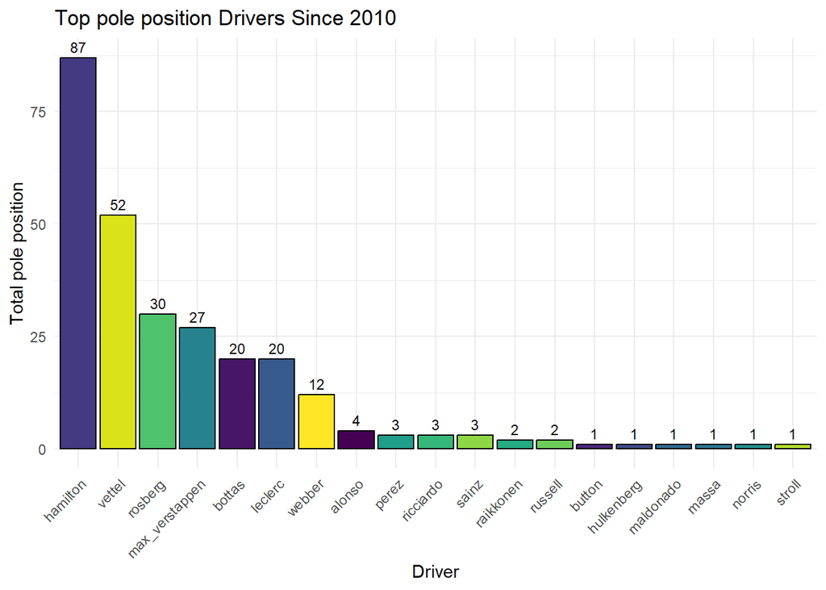

```r
# Summarize total pole position for each driver
top_poleposition_drivers <- merged_data %>%
  filter(grid == 1) %>%
  group_by(driverId) %>%
  summarize(total_poleposition = n())


# Merge with driver information
top_poleposition_drivers <- top_poleposition_drivers %>%
  inner_join(drivers_df, by = "driverId")


# Plot the results
ggplot(top_poleposition_drivers, aes(x = reorder(driverRef, -total_poleposition), y = total_poleposition, fill = driverRef)) +
  geom_bar(stat = "identity", color = "black") +
  geom_text(aes(label = total_poleposition), vjust = -0.5, size = 3) +
  labs(title = "Top pole position Drivers Since 2010",
       x = "Driver",
       y = "Total pole position") +
  scale_fill_viridis(discrete = TRUE, option = "D") +
  theme_minimal() +
  theme(axis.text.x = element_text(angle = 45, hjust = 1),
        legend.position = "none")
```

In the realm of pole positions, Lewis Hamilton dominates as the most prolific driver with an impressive tally of 87, firmly securing the top spot. Sebastian Vettel follows with 52 pole positions. A compelling twist unfolds as Max Verstappen, while not in the top 3 for pole positions, remarkably claims a spot among the top 3 for total wins, highlighting a distinct strength in race execution and strategic prowess.

```r
races_since_2010 <- races_df %>%
  filter(year >= 2010)

constructors_wins <- races_since_2010 %>%
  left_join(constructors_results_df, by = "raceId") %>%
  group_by(raceId) %>%
  filter(points == max(points, na.rm = TRUE)) %>%
  group_by(constructorId) %>%
  summarize(total_wins = n())
```

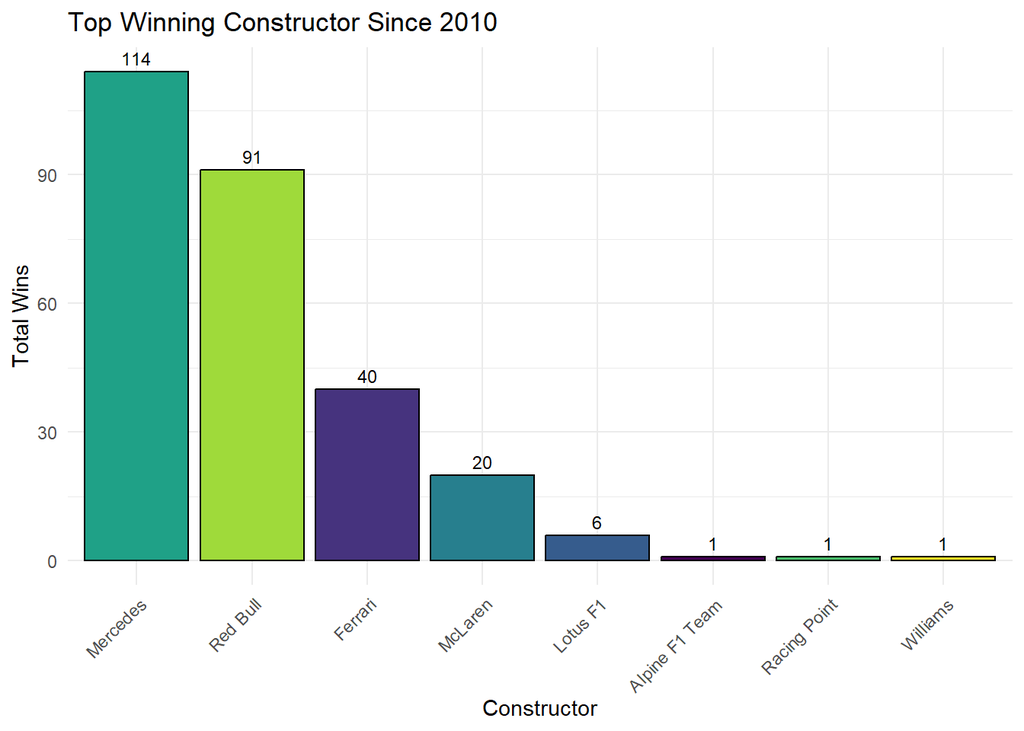

```r
# Merge with constructor information
top_winning_constructors <- constructors_wins %>%
  inner_join(constructors_df, by = "constructorId")

# Create a bar plot for the top winning constructor
ggplot(top_winning_constructors, aes(x = reorder(name, -total_wins), y = total_wins, fill = name)) +
  geom_bar(stat = "identity", color = "black") +
  labs(title = "Top Winning Constructor Since 2010",
       x = "Constructor",
       y = "Total Wins") +
  scale_fill_viridis(discrete = TRUE, option = "D") +
  theme_minimal() +
  theme(axis.text.x = element_text(angle = 45, hjust = 1),
        legend.position = "none") +
  geom_text(aes(label = total_wins), vjust = -0.5, color = "black", size = 3)
```

In the realm of Formula 1 constructors, Mercedes stands out as the most dominant force, clinching an impressive 114 victories. Red Bull follows closely behind, securing a commendable tally of 91 wins, establishing themselves as a formidable powerhouse in the world of motorsport.

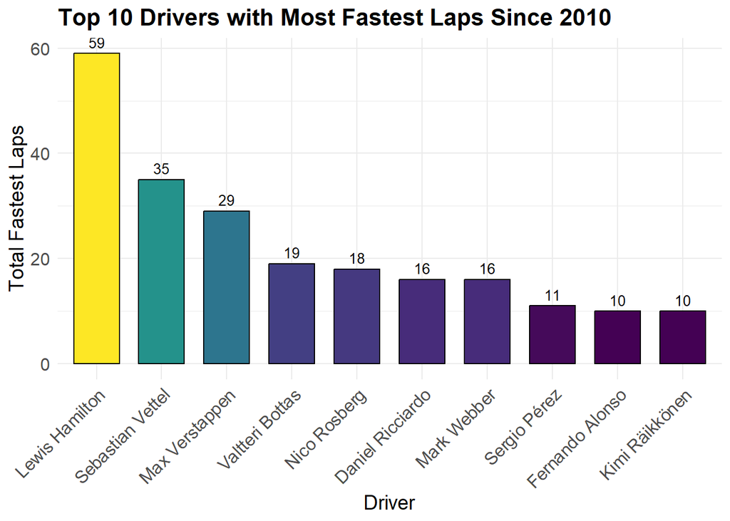

```r
# Filter data for races since 2010
lap_times_since_2010 <- lap_times_df %>%
  inner_join(races_df, by = "raceId") %>%
  filter(year >= 2010)

# Find the fastest lap for each race
fastest_laps <- lap_times_since_2010 %>%
  filter(!is.na(milliseconds)) %>%  # Remove laps without recorded time
  group_by(raceId) %>%
  arrange(milliseconds) %>%
  slice_head()  # Keep only the fastest lap for each race

# Count the number of fastest laps for each driver
fastest_laps_count <- fastest_laps %>%
  group_by(driverId) %>%
  summarize(total_fastest_laps = n()) %>%
  top_n(10, total_fastest_laps)  # Select the top 10 drivers

# Merge with driver information
top_fastest_drivers <- fastest_laps_count %>%
  inner_join(drivers_df, by = "driverId")

# Plot the top 10 drivers with adjusted proportions
ggplot(top_fastest_drivers, aes(x = reorder(paste(forename, surname), -total_fastest_laps), y = total_fastest_laps, fill = total_fastest_laps)) +
  geom_bar(stat = "identity", color = "black", position = position_dodge(width = 0.8), width = 0.7) +
  geom_text(aes(label = total_fastest_laps), vjust = -0.5, size = 3.5, color = "black") +
  scale_fill_gradientn(colors = viridis(10)) +
  labs(title = "Top 10 Drivers with Most Fastest Laps Since 2010",
       x = "Driver",
       y = "Total Fastest Laps") +
  theme_minimal() +
  theme(axis.text.x = element_text(angle = 45, hjust = 1, vjust = 1),
        plot.title = element_text(size = 16, face = "bold"),
        axis.text = element_text(size = 12),
        axis.title = element_text(size = 14),
        legend.position = "none")  # Hide legend for better clarity
```

Lewis Hamilton leads the pack as the driver with the most fastest laps since 2010, boasting an impressive total of 59 fastest laps. Sebastian Vettel secures the second position with 35 fastest laps, closely followed by Max Verstappen with 29 fastest laps.

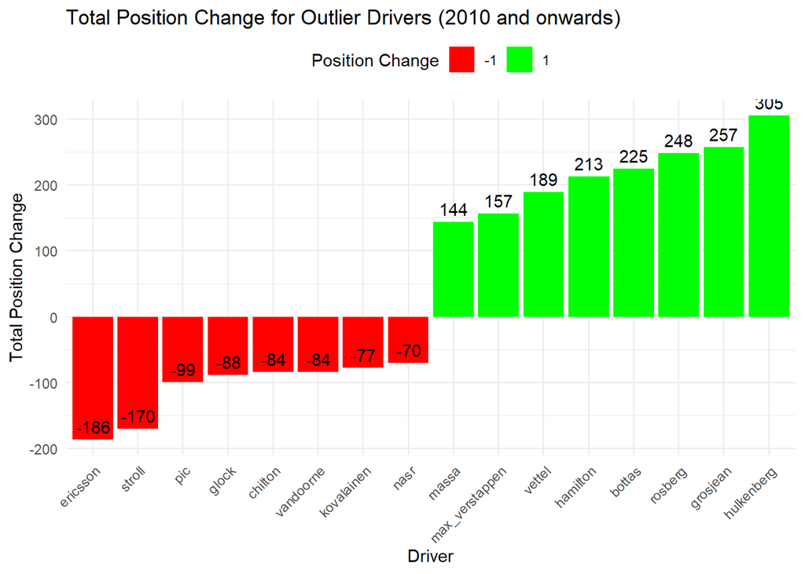

```r
# Calculate the total position change for each driver
driver_position_change <- merged_data %>%
  group_by(driverId) %>%
  summarize(total_position_change = sum(positionOrder - grid))

# Join with drivers_df to get driver names
driver_position_change <- driver_position_change %>%
  inner_join(drivers_df, by = "driverId")

# Order the data by total position change
driver_position_change <- driver_position_change %>%
  arrange(total_position_change)

# Calculate the number of observations
num_obs <- nrow(driver_position_change)

# Calculate the indices for the first and last tenth
first_tenth_index <- round(0.1 * num_obs)
last_tenth_index <- round(0.9 * num_obs)

# Filter the data to include only the first and last tenth
outliers <- driver_position_change %>%
  filter(row_number() <= first_tenth_index | row_number() > last_tenth_index)

# Create a bar plot for outliers with labels
ggplot(outliers, aes(x = reorder(driverRef, total_position_change), y = total_position_change)) +
  geom_col(aes(fill = factor(sign(total_position_change)))) +
  geom_text(aes(label = total_position_change), vjust = -0.5, color = "black") +
  scale_fill_manual(values = c("red", "green"), name = "Position Change") +
  labs(title = "Total Position Change for Outlier Drivers (2010 and onwards)",
       x = "Driver",
       y = "Total Position Change") +
  theme_minimal() +
  theme(axis.text.x = element_text(angle = 45, hjust = 1),
        legend.position = "top")
```

```r
# Calculate the total number of races for each grid position
total_races_per_grid <- table(merged_data$grid)

# Calculate the number of wins for each grid position
wins_per_grid <- table(merged_data$grid[merged_data$positionOrder == 1])

# Ensure the vectors have the same length
all_grid_positions <- 1:max(as.numeric(names(total_races_per_grid)), as.numeric(names(wins_per_grid)))
total_races_per_grid <- total_races_per_grid[as.character(all_grid_positions)]
wins_per_grid <- wins_per_grid[as.character(all_grid_positions)]

# Calculate the winning percentage for each grid position
winning_percentage_per_grid <- wins_per_grid / total_races_per_grid * 100

# Display the winning percentage for the first grid position
cat("Winning percentage for the first grid position:", ifelse(1 %in% all_grid_positions, winning_percentage_per_grid[as.character(1)], 0), "%\n")
```

```
## Winning percentage for the first grid position: 51.29151 %
```

The winning percentage for the first grid position is 51.3%.

```r
# Calculate the total number of races for each grid position
total_races_per_grid <- table(merged_data$grid)

# Calculate the number of wins for each grid position
wins_per_grid <- table(merged_data$grid[merged_data$positionOrder == 1])

# Ensure the vectors have the same length
all_grid_positions <- 1:max(as.numeric(names(total_races_per_grid)), as.numeric(names(wins_per_grid)))
total_races_per_grid <- total_races_per_grid[as.character(all_grid_positions)]
wins_per_grid <- wins_per_grid[as.character(all_grid_positions)]

# Calculate the winning percentage for each grid position
winning_percentage_per_grid <- wins_per_grid / total_races_per_grid * 100

# Create a data frame with grid position and winning percentage
ordered_results <- data.frame(grid_position = as.numeric(names(winning_percentage_per_grid)),
                              winning_percentage = winning_percentage_per_grid)

# Remove rows with NA values in winning_percentage
ordered_results <- na.omit(ordered_results)

# Drop the "winning_percentage.Var1" column
ordered_results <- subset(ordered_results, select = -c(winning_percentage.Var1))

# Order the results by winning percentage in descending order
ordered_results <- ordered_results[order(ordered_results$winning_percentage.Freq, decreasing = TRUE), ]

# Display the ordered results
cat("Grid positions ordered by winning percentage:\n")
```

```
## Grid positions ordered by winning percentage:
```

```r
print(ordered_results)
```

```
##    grid_position winning_percentage.Freq
## 1              1              51.2915129
## 2              2              25.9259259
## 3              3              10.7011070
## 4              4               3.3210332
## 6              6               2.2140221
## 5              5               1.8450185
## 10            10               1.4869888
## 7              7               1.1111111
## 8              8               0.7407407
## 14            14               0.7407407
## 11            11               0.3717472
## 9              9               0.3690037
```

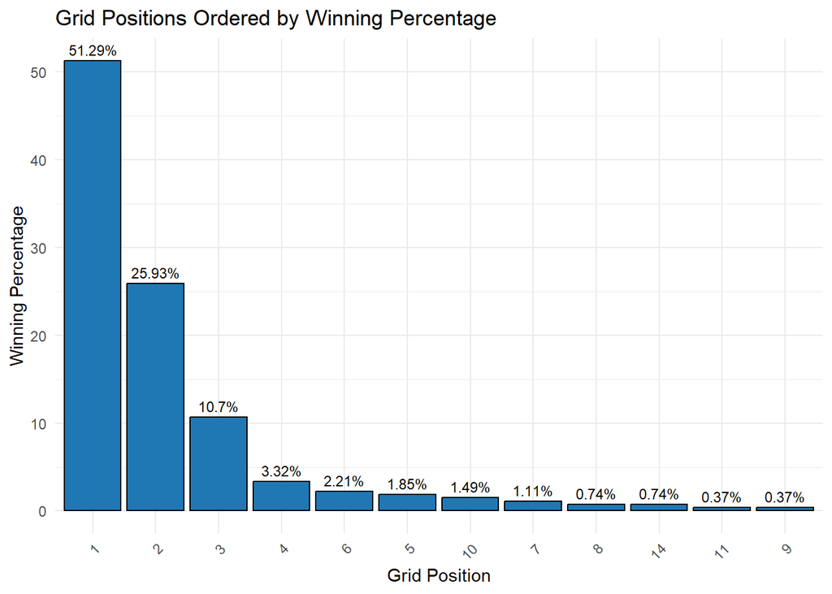

```r
ggplot(ordered_results, aes(x = reorder(factor(grid_position), -winning_percentage.Freq), y = winning_percentage.Freq)) +
  geom_bar(stat = "identity", fill = "#1f78b4", color = "black") +
  labs(title = "Grid Positions Ordered by Winning Percentage",
       x = "Grid Position",
       y = "Winning Percentage") +
  theme_minimal() +
  theme(axis.text.x = element_text(angle = 45, hjust = 1)) +
  geom_text(aes(label = paste0(round(winning_percentage.Freq, 2), "%")), vjust = -0.5, size = 3) +  # Label with percentage
  scale_fill_manual(values = "#1f78b4")  # Matching color for bars
```

The plot above shows the winning percentage for each grid position. The grid position with the highest winning percentage is the first grid position, with a winning percentage of 51.3%. The grid position with the second highest winning percentage is the second grid position, with a winning percentage of 25.9%. The grid position with the third highest winning percentage is the third grid position, with a winning percentage of 10.7%. It’s interesting to see that the 87,9% of the total races are won by the first three grid positions.

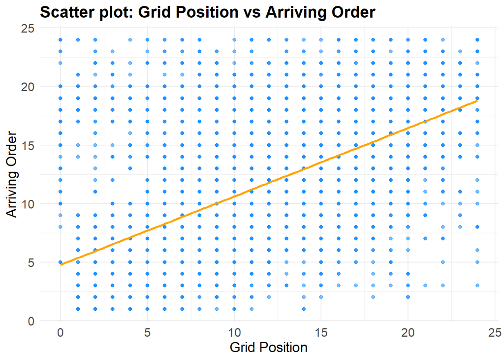

```r
# Scatter plot with regression line
ggplot(merged_data, aes(x = grid, y = positionOrder)) +
  geom_point(alpha = 0.6, color = "dodgerblue") +
  geom_smooth(method = "lm", se = FALSE, color = "orange") +
  labs(title = "Scatter plot: Grid Position vs Arriving Order",
       x = "Grid Position", y = "Arriving Order") +
  theme_minimal() +
  theme(plot.title = element_text(size = 16, face = "bold"),
        axis.text = element_text(size = 12),
        axis.title = element_text(size = 14),
        legend.position = "none")
```

The plot above shows the relationship between grid position and arriving order. The orange line is the regression line. The regression line shows that there is a positive relationship between grid position and arriving order. This means that the higher the grid position, the higher the arriving order.

```r
# Create a binary variable indicating whether the driver won or not
merged_data$win <- ifelse(merged_data$positionOrder == 1, 1, 0)

# Logistic regression model
logistic_model_since_2010 <- glm(win ~ grid, data = merged_data, family = "binomial")

# Model summary
summary(logistic_model_since_2010)
```

```
##
## Call:
## glm(formula = win ~ grid, family = "binomial", data = merged_data)
##
## Coefficients:
##             Estimate Std. Error z value Pr(>|z|)
## (Intercept) -0.05364    0.11366  -0.472    0.637
## grid        -0.59596    0.03613 -16.493   <2e-16 ***
## ---
## Signif. codes:  0 '***' 0.001 '**' 0.01 '*' 0.05 '.' 0.1 ' ' 1
##
## (Dispersion parameter for binomial family taken to be 1)
##
##     Null deviance: 2185.4  on 5756  degrees of freedom
## Residual deviance: 1360.6  on 5755  degrees of freedom
## AIC: 1364.6
##
## Number of Fisher Scoring iterations: 9
```

```r
# Create a dataframe with desired starting positions
grid_values <- data.frame(grid = 1:20)

# Calculate estimated win probabilities for each starting position
predicted_probs <- predict(logistic_model_since_2010, newdata = grid_values, type = "response")

# Combine starting positions and estimated win probabilities in a dataframe
predicted_data <- data.frame(grid = grid_values$grid, predicted_prob = predicted_probs)

# Print the resulting dataframe
print(predicted_data)
```

```
##    grid predicted_prob
## 1     1   3.430805e-01
## 2     2   2.234703e-01
## 3     3   1.368721e-01
## 4     4   8.035924e-02
## 5     5   4.593800e-02
## 6     6   2.584645e-02
## 7     7   1.440947e-02
## 8     8   7.991799e-03
## 9     9   4.419606e-03
## 10   10   2.440193e-03
## 11   11   1.346102e-03
## 12   12   7.421959e-04
## 13   13   4.091111e-04
## 14   14   2.254753e-04
## 15   15   1.242570e-04
## 16   16   6.847357e-05
## 17   17   3.773239e-05
## 18   18   2.079216e-05
## 19   19   1.145728e-05
## 20   20   6.313377e-06
```

The code presented above illuminates the estimated probabilities of winning a Grand Prix associated with different starting grid positions. Leveraging the logistic regression model (glm), these probabilities are derived, revealing a statistically significant relationship between a driver’s grid position and their likelihood of securing a victory.

The negative coefficient for the “grid” variable in the logistic regression model signifies that higher grid positions are correlated with lower odds of winning. The model demonstrates a robust fit, supported by the low residual deviance and AIC values.

```r
# Calculate the correlation for each season
seasonal_correlations <- merged_data %>%
  group_by(year) %>%
  summarize(correlation = cor(grid, positionOrder, use = "complete.obs"))

# Calculate the overall correlation across all seasons
overall_correlation <- cor(merged_data$grid, merged_data$positionOrder, use = "complete.obs")

# Perform linear regression
lm_model <- lm(positionOrder ~ grid, data = merged_data)

# Print the results

print(summary(lm_model))
```

```
##
## Call:
## lm(formula = positionOrder ~ grid, data = merged_data)
##
## Residuals:
##     Min      1Q  Median      3Q     Max
## -15.790  -3.611  -1.027   2.726  19.231
##
## Coefficients:
##             Estimate Std. Error t value Pr(>|t|)
## (Intercept)  4.76935    0.13394   35.61   <2e-16 ***
## grid         0.58417    0.01058   55.19   <2e-16 ***
## ---
## Signif. codes:  0 '***' 0.001 '**' 0.01 '*' 0.05 '.' 0.1 ' ' 1
##
## Residual standard error: 5.047 on 5755 degrees of freedom
## Multiple R-squared:  0.3461, Adjusted R-squared:  0.346
## F-statistic:  3046 on 1 and 5755 DF,  p-value: < 2.2e-16
```

```r
cat("Overall Correlation across all seasons from 2010:", overall_correlation, "\n")
```

```
## Overall Correlation across all seasons from 2010: 0.5883153
```

```r
cat("Seasonal Correlations:\n")
```

```
## Seasonal Correlations:
```

```r
print(seasonal_correlations)
```

```
## # A tibble: 14 × 2
##     year correlation
##    <int>       <dbl>
##  1  2010       0.627
##  2  2011       0.623
##  3  2012       0.492
##  4  2013       0.670
##  5  2014       0.609
##  6  2015       0.612
##  7  2016       0.605
##  8  2017       0.554
##  9  2018       0.564
## 10  2019       0.567
## 11  2020       0.560
## 12  2021       0.578
## 13  2022       0.478
## 14  2023       0.557
```

```r
cat("\nLinear Regression Coefficients:\n")
```

```
##
## Linear Regression Coefficients:
```

The code showcased above provides a detailed examination of the correlation between grid position and race results, individually assessed for each season. Furthermore, it calculates the overarching correlation across all seasons, culminating in an overall correlation coefficient of 0.588. To delve even deeper, the code undertakes a linear regression model, shedding light on the quantitative relationship between grid positions and final race standings.

```r
# Check correlation and perform linear regression between grid position and arriving order
# Get a vector of unique circuit IDs since 2010
unique_circuits <- races_data %>%
  distinct(circuitId)

# Function to perform analysis for a specific circuit
analyze_circuit <- function(circuit_id) {
  # Filter results data for the selected circuit
  results_data <- results_df %>%
    inner_join(races_data %>% filter(circuitId == circuit_id), by = "raceId") %>%
    select(raceId, year, grid, positionOrder) %>%
    drop_na(grid, positionOrder)  # Remove rows with missing values

  # Calculate the overall correlation across all seasons
  overall_correlation <- if (nrow(results_data) > 1) {
    cor(results_data$grid, results_data$positionOrder, use = "complete.obs")
  } else {
    NA
  }

  # Retrieve circuit name from circuits_df
  circuit_name <- circuits_df %>%
    filter(circuitId == circuit_id) %>%
    pull(name)

  # Return results
  return(data.frame(circuitId = circuit_id,
                    name = circuit_name,
                    overall_correlation = overall_correlation))
}

# Apply the analysis function to each circuit
results_circuits <- unique_circuits %>%
  rowwise() %>%
  do(analyze_circuit(.))

# Order results by overall correlation
results_circuits <- results_circuits %>%
  arrange(desc(overall_correlation))

# Print the ordered results
print(results_circuits, n = nrow(results_circuits))
```

```
## # A tibble: 35 × 3
## # Rowwise:
##    circuitId name                                 overall_correlation
##        <int> <chr>                                              <dbl>
##  1        75 Autódromo Internacional do Algarve                 0.827
##  2        39 Circuit Park Zandvoort                             0.728
##  3        17 Shanghai International Circuit                     0.728
##  4        32 Autódromo Hermanos Rodríguez                       0.718
##  5        34 Circuit Paul Ricard                                0.692
##  6        68 Buddh International Circuit                        0.686
##  7         4 Circuit de Barcelona-Catalunya                     0.659
##  8        24 Yas Marina Circuit                                 0.644
##  9         3 Bahrain International Circuit                      0.640
## 10         7 Circuit Gilles Villeneuve                          0.639
## 11         5 Istanbul Park                                      0.634
```

[output cut: 24 more lines]

```r
# Filter circuits with races since 2010
filtered_circuits <- circuits_df %>%
  inner_join(races_data %>% filter(year >= 2010), by = "circuitId") %>%
  distinct(circuitId, circuit_name = name.x, location, country, lat, lng, alt)

# Add overall correlation to the filtered circuits
filtered_circuits <- filtered_circuits %>%
  left_join(results_circuits, by = "circuitId")

# Create a leaflet map
world_map <- leaflet(data = filtered_circuits) %>%
  addTiles() %>%
  addMarkers(
    lat = ~lat,
    lng = ~lng,
    popup = ~paste(circuit_name, "<br>", "Location:", location, "<br>", "Country:", country, "<br>", "Altitude:", alt, "m", "<br>", "Overall Correlation:", overall_correlation)
  )

# Print the map
print(world_map)
```

The provided code unveils a detailed exploration of the correlation between grid position and race results, distinctly examined for each circuit. Additionally, the code crafts a visual representation of the global circuit landscape through an interactive map, where each circuit is denoted by a marker.

```r
# Get a vector of unique driver IDs
unique_drivers <- merged_data %>%
  distinct(driverId)

# Function to perform analysis for a specific driver
analyze_driver <- function(driver_id) {
  # Filter merged data for the selected driver
  driver_data <- merged_data %>%
    filter(driverId == driver_id) %>%
    select(raceId, year, grid, positionOrder) %>%
    drop_na(grid, positionOrder)  # Remove rows with missing values

  # Calculate the overall correlation across all races
  overall_correlation <- if (nrow(driver_data) > 1) {
    cor(driver_data$grid, driver_data$positionOrder, use = "complete.obs")
  } else {
    NA
  }

  # Retrieve driver info from drivers_df
  driver_info <- drivers_df %>%
    filter(driverId == driver_id) %>%
    select(name = driverRef, nationality)

  # Return results
  return(data.frame(driverId = driver_id,
                    name = driver_info$name,
                    nationality = driver_info$nationality,
                    overall_correlation = overall_correlation))
}

# Apply the analysis function to each driver
results_drivers <- unique_drivers %>%
  rowwise() %>%
  do(analyze_driver(.))

# Order results by overall correlation
results_drivers <- results_drivers %>%
  arrange(desc(overall_correlation))

# Print the ordered results
print(results_drivers, n = nrow(results_drivers))
```

```
## # A tibble: 76 × 4
## # Rowwise:
##    driverId name               nationality   overall_correlation
##       <dbl> <chr>              <chr>                       <dbl>
##  1      858 sargeant           American                  0.603
##  2      847 russell            British                   0.568
##  3      811 bruno_senna        Brazilian                 0.566
##  4       18 button             British                   0.512
##  5      822 bottas             Finnish                   0.510
##  6      857 piastri            Australian                0.510
##  7      817 ricciardo          Australian                0.485
##  8      848 albon              Thai                      0.483
##  9        4 alonso             Spanish                   0.480
## 10      846 norris             British                   0.476
## 11      844 leclerc            Monegasque                0.472
```

[output cut: 65 more lines]

The code displays the correlation between grid position and arriving order for each driver.

```r
# Get a vector of unique constructor IDs
unique_constructors <- merged_data %>%
  distinct(constructorId)

# Function to perform analysis for a specific constructor
analyze_constructor <- function(constructor_id) {
  # Filter results data for the selected constructor
  constructor_results <- merged_data %>%
    filter(constructorId == constructor_id) %>%
    select(resultId, raceId, grid, positionOrder) %>%
    drop_na(grid, positionOrder)  # Remove rows with missing values

  # Calculate the overall correlation across all races
  overall_correlation <- if (nrow(constructor_results) > 1) {
    cor(constructor_results$grid, constructor_results$positionOrder, use = "complete.obs")
  } else {
    NA
  }

  # Retrieve constructor name from constructor_df
  constructor_name <- constructors_df %>%
    filter(constructorId == constructor_id) %>%
    pull(name)

  # Return results
  return(data.frame(constructorId = constructor_id,
                    name = constructor_name,
                    overall_correlation = overall_correlation))
}

# Apply the analysis function to each constructor
results_constructors <- unique_constructors %>%
  rowwise() %>%
  do(analyze_constructor(.))

# Order results by overall correlation
results_constructors <- results_constructors %>%
  arrange(desc(overall_correlation))

# Print the ordered results
print(results_constructors, n = nrow(results_constructors))
```

```
## # A tibble: 22 × 3
## # Rowwise:
##    constructorId name           overall_correlation
##            <dbl> <chr>                        <dbl>
##  1             3 Williams                    0.461
##  2           211 Racing Point                0.431
##  3             4 Renault                     0.426
##  4             1 McLaren                     0.423
##  5           117 Aston Martin                0.412
##  6           208 Lotus F1                    0.369
##  7            10 Force India                 0.340
##  8           131 Mercedes                    0.330
##  9           210 Haas F1 Team                0.321
## 10             6 Ferrari                     0.285
## 11           213 AlphaTauri                  0.265
## 12           214 Alpine F1 Team              0.260
## 13            51 Alfa Romeo                  0.240
## 14             9 Red Bull                    0.219
## 15            15 Sauber                      0.137
## 16             5 Toro Rosso                  0.113
## 17           209 Manor Marussia              0.0447
## 18           207 Caterham                    0.0166
## 19           205 Lotus                      -0.0143
## 20           206 Marussia                   -0.0548
## 21           166 Virgin                     -0.0676
## 22           164 HRT                        -0.247
```

The code above displays the correlation between grid position and arriving order for each constructor.

```r
#average pit stop duration for winning drivers
merge_dataset <- pit_stops_df %>%
  inner_join(merged_data, by = c("raceId", "driverId")) %>%
  filter(positionOrder == 1)

# Convert milliseconds.x to numeric
merge_dataset <- merge_dataset %>%
  mutate(milliseconds = as.numeric(milliseconds))

#Filter out data where milliseconds.x is more than 30 seconds
filtered_data <- merge_dataset %>%
 filter(milliseconds <= 36691.125)

summary_statistics <- filtered_data %>%
  summarise(
    average_milliseconds = mean(milliseconds, na.rm = TRUE),
    median_milliseconds = median(milliseconds, na.rm = TRUE),
    sd_milliseconds = sd(milliseconds, na.rm = TRUE),
    var_milliseconds = var(milliseconds, na.rm = TRUE),
    min_milliseconds = min(milliseconds, na.rm = TRUE),
    max_milliseconds = max(milliseconds, na.rm = TRUE),
    range_milliseconds = max_milliseconds - min_milliseconds,
    quantile_25 = quantile(milliseconds, 0.25, na.rm = TRUE),
    quantile_75 = quantile(milliseconds, 0.75, na.rm = TRUE),
    interquartile_range = quantile_75 - quantile_25
  )

# Print the average milliseconds
print(summary_statistics)
```

```
## # A tibble: 1 × 10
##   average_milliseconds median_milliseconds sd_milliseconds var_milliseconds
##                  <dbl>               <dbl>           <dbl>            <dbl>
## 1               23067.              22602.           3187.        10156161.
## # ℹ 6 more variables: min_milliseconds <dbl>, max_milliseconds <dbl>,
## #   range_milliseconds <dbl>, quantile_25 <dbl>, quantile_75 <dbl>,
## #   interquartile_range <dbl>
```

the code shows the average, median, standard deviation, variance, minimum, maximum, range, 25th percentile, 75th percentile, and interquartile range of the pit stop duration for winning drivers. I decided to eliminate the outliers from the dataset, as they are not representative of the average pit stop duration. I used the 1.5*IQR rule to identify the outliers. The outliers are the pit stops that are more than 1.5 times the interquartile range (IQR) below the first quartile or above the third quartile. The IQR is the difference between the third quartile and the first quartile. The first quartile is the 25th percentile and the third quartile is the 75th percentile. The 1.5*IQR rule is a common rule of thumb to identify outliers. It is not a hard and fast rule, but it is a good starting point.

```r
# Join with pit_stops_df and circuits_df
pit_stops_drivers <- merged_data %>%
  inner_join(pit_stops_df, by = c("raceId", "driverId"))


# Find the pit stops that are longer than 36691.125 milliseconds (outliers) and change the value with the average of the pit stops which is 23066.89 milliseconds
pit_stops_drivers <- pit_stops_drivers %>%
  mutate(milliseconds = ifelse(milliseconds > 36691.125, 23066.89, milliseconds))

# Convert milliseconds to numeric, handling non-numeric values and NAs
pit_stops_drivers <- pit_stops_drivers %>%
  mutate(milliseconds = as.numeric(milliseconds))

# Calculate the total number of pit stops for each raceId and circuitId
# Divide by the number of unique drivers who did at least one pit stop
total_pitstops_per_race <- pit_stops_drivers %>%
  group_by(raceId, circuitId) %>%
  summarise(
    total_pitstops = n()
  )
pit_stop_total_drivers <- pit_stops_drivers %>%
  group_by(raceId, circuitId) %>%
  summarise(
    total_drivers_with_pitstop = n_distinct(driverId)
  )
total_pitstops_per_race <- total_pitstops_per_race %>%
  inner_join(pit_stop_total_drivers, by = c("raceId", "circuitId")) %>%
  mutate(total_pitstops = total_pitstops / total_drivers_with_pitstop)

# Calculate average pit stop duration for each raceId and circuitId
average_pitstop_duration <- pit_stops_drivers %>%
  group_by(raceId, circuitId) %>%
  summarise(
    average_duration = mean(milliseconds, na.rm = TRUE)
  )
# Inner join between total_pitstops_per_race and average_pitstop_duration on raceId and circuitId
result_data <- inner_join(total_pitstops_per_race, average_pitstop_duration, by = c("raceId", "circuitId"))

# Join with circuits_df to get circuit information
result_data <- inner_join(result_data, circuits_df, by = "circuitId")

# Calculate average pit stop duration and number for each circuit
average_pitstops_duration_per_circuit <- result_data %>%
  group_by(circuitId, name, location, country) %>%
  summarise(
    average_pitstops = mean(total_pitstops),
    average_duration = mean(average_duration)
  )
# Order the dataset by average duration
average_pitstops_duration_per_circuit <- average_pitstops_duration_per_circuit %>%
  arrange(average_pitstops)

# Print the ordered dataset and overall average
print(average_pitstops_duration_per_circuit)
```

```
## # A tibble: 34 × 6
## # Groups:   circuitId, name, location [34]
##    circuitId name             location country average_pitstops average_duration
##        <dbl> <chr>            <chr>    <chr>              <dbl>            <dbl>
##  1        79 Miami Internati… Miami    USA                 1.16           21368.
##  2        34 Circuit Paul Ri… Le Cast… France              1.19           28522.
##  3        71 Sochi Autodrom   Sochi    Russia              1.32           30035.
##  4        14 Autodromo Nazio… Monza    Italy               1.43           24895.
##  5        32 Autódromo Herma… Mexico … Mexico              1.45           23348.
##  6        78 Losail Internat… Al Daay… Qatar               1.5            26418.
##  7        77 Jeddah Corniche… Jeddah   Saudi …             1.60           22373.
##  8        24 Yas Marina Circ… Abu Dha… UAE                 1.61           22200.
##  9         6 Circuit de Mona… Monte-C… Monaco              1.62           25797.
## 10         7 Circuit Gilles … Montreal Canada              1.71           23804.
## # ℹ 24 more rows
```

The provided code showcases the presentation of both the average duration and the average quantity of pit stops for each circuit.

```r
grand_prix_winners <- merged_data %>%
  filter(positionOrder == 1)

# Join with pit_stops_df and circuits_df
pit_stops_winners <- grand_prix_winners %>%
  inner_join(pit_stops_df, by = c("raceId", "driverId"))

#find the pit stops that are longer than 36691.125 milliseconds and change the value with the average of the pit stops which is 23066.89 milliseconds
pit_stops_winners <- pit_stops_winners %>%
  mutate(milliseconds = ifelse(milliseconds > 36691.125, 23066.89, milliseconds))

# Convert milliseconds to numeric, handling non-numeric values and NAs
pit_stops_winners <- pit_stops_winners %>%
  mutate(milliseconds = as.numeric(milliseconds))

# Calculate the total number of pit stops for each raceId and circuitId
total_pitstops_winners <- pit_stops_winners %>%
  group_by(raceId, circuitId) %>%
  summarise(
    total_pitstops = n()
  )
# Calculate average pit stop duration for each raceId and circuitId
average_pitstop_winners <- pit_stops_winners %>%
  group_by(raceId, circuitId) %>%
  summarise(
    average_duration = mean(milliseconds, na.rm = TRUE)
  )
# Inner join between total_pitstops_per_race and average_pitstop_winners on raceId and circuitId
result_data <- inner_join(total_pitstops_winners, average_pitstop_winners, by = c("raceId", "circuitId"))

# Join with circuits_df to get circuit information
result_data <- inner_join(result_data, circuits_df, by = "circuitId")

# Calculate average pit stop duration and number for each circuit
average_pitstop_winners <- result_data %>%
  group_by(circuitId, name, location, country) %>%
  summarise(
    average_pitstops = mean(total_pitstops),
    average_duration = mean(average_duration)
  )
# Order the dataset by average duration
average_pitstop_winners <- average_pitstop_winners %>%
  arrange(average_pitstops)

# Print the ordered dataset and overall average
print(average_pitstop_winners)
```

```
## # A tibble: 34 × 6
## # Groups:   circuitId, name, location [34]
##    circuitId name             location country average_pitstops average_duration
##        <dbl> <chr>            <chr>    <chr>              <dbl>            <dbl>
##  1        79 Miami Internati… Miami    USA                 1              20743
##  2        71 Sochi Autodrom   Sochi    Russia              1.12           29850.
##  3         6 Circuit de Mona… Monte-C… Monaco              1.17           25062.
##  4        14 Autodromo Nazio… Monza    Italy               1.25           23649.
##  5        34 Circuit Paul Ri… Le Cast… France              1.25           29931.
##  6        32 Autódromo Herma… Mexico … Mexico              1.29           22203.
##  7        24 Yas Marina Circ… Abu Dha… UAE                 1.58           21449.
##  8        69 Circuit of the … Austin   USA                 1.6            24007.
##  9         1 Albert Park Gra… Melbour… Austra…             1.64           22204.
## 10        68 Buddh Internati… Uttar P… India               1.67           21974.
## # ℹ 24 more rows
```

The provided code highlights the presentation of average pit stop duration and average pit stop quantity for each circuit, specifically focusing on winning drivers.

```r
# Calculate the ratio for each row
ratio_data <- average_pitstop_winners %>%
  inner_join(average_pitstops_duration_per_circuit, by = c("circuitId", "name", "location", "country")) %>%
  mutate(
    ratio_pitstops = average_pitstops.x / average_pitstops.y,
    ratio_duration = average_duration.x / average_duration.y
  ) %>%
  select(circuitId, name, location, country, ratio_pitstops, ratio_duration)

# Print the result
print(ratio_data)
```

```
## # A tibble: 34 × 6
## # Groups:   circuitId, name, location [34]
##    circuitId name                 location country ratio_pitstops ratio_duration
##        <dbl> <chr>                <chr>    <chr>            <dbl>          <dbl>
##  1        79 Miami International… Miami    USA              0.864          0.971
##  2        71 Sochi Autodrom       Sochi    Russia           0.854          0.994
##  3         6 Circuit de Monaco    Monte-C… Monaco           0.720          0.971
##  4        14 Autodromo Nazionale… Monza    Italy            0.872          0.950
##  5        34 Circuit Paul Ricard  Le Cast… France           1.05           1.05
##  6        32 Autódromo Hermanos … Mexico … Mexico           0.886          0.951
##  7        24 Yas Marina Circuit   Abu Dha… UAE              0.983          0.966
##  8        69 Circuit of the Amer… Austin   USA              0.915          0.970
##  9         1 Albert Park Grand P… Melbour… Austra…          0.870          0.973
## 10        68 Buddh International… Uttar P… India            0.926          0.934
## # ℹ 24 more rows
```

```r
# Use the mean function to calculate the average, and na.rm = TRUE to handle missing values
overall_pitstop_duration <- mean(ratio_data$ratio_duration, na.rm = TRUE)
overall_pitstops <- mean(ratio_data$ratio_pitstops, na.rm = TRUE)

# Print the result
print(paste("The average of 'ratio_duration' in 'ratio_data' is:", round(overall_pitstop_duration, 2)))
```

```
## [1] "The average of 'ratio_duration' in 'ratio_data' is: 0.96"
```

```r
print(paste("The average of 'ratio_pitstops' in 'ratio_data' is:", round(overall_pitstops, 2)))
```

```
## [1] "The average of 'ratio_pitstops' in 'ratio_data' is: 0.98"
```

These findings suggest that, on average, drivers in the first position tend to have fewer pit stops and shorter pit stop durations compared to other drivers in the race.

### 5.2 Correlation Sprint race and Qualifying

```r
# Filter and clean results data for the selected races
merged_data_sprint <- sprint_results_df %>%
  inner_join(races_data, by = "raceId") %>%
  filter(!is.na(grid) & !is.na(positionOrder))  # Remove rows with missing values

# Initialize a list to store correlation results for each season
correlation_results_sprint <- list()

# Get unique seasons
unique_seasons_sprint <- unique(merged_data_sprint$year)
unique_seasons_sprint <- unique_seasons_sprint[order(unique_seasons_sprint)]  # Corrected variable name

# Loop over each season
for (season in unique_seasons_sprint) {
  # Subset data for the current season
  season_data_sprint <- merged_data_sprint[merged_data_sprint$year == season, ]

  # Calculate Pearson correlation coefficient
  pearson_corr_sprint <- cor(season_data_sprint$grid, season_data_sprint$positionOrder, method = "pearson")

  # Calculate Spearman correlation coefficient
  spearman_corr_sprint <- cor(season_data_sprint$grid, season_data_sprint$positionOrder, method = "spearman")

  # Store results in the list
  correlation_results_sprint[[as.character(season)]] <- c(pearson_corr = pearson_corr_sprint, spearman_corr = spearman_corr_sprint)
}

# Display the correlation results for each season
for (season in unique_seasons_sprint) {
  cat("Season:", season, "\n")
  cat("  Pearson correlation:", correlation_results_sprint[[as.character(season)]]["pearson_corr"], "\n")
  cat("  Spearman correlation:", correlation_results_sprint[[as.character(season)]]["spearman_corr"], "\n")
}
```

```
## Season: 2021
##   Pearson correlation: 0.7904762
##   Spearman correlation: 0.7904762
## Season: 2022
##   Pearson correlation: 0.636198
##   Spearman correlation: 0.6380686
## Season: 2023
##   Pearson correlation: 0.5772091
##   Spearman correlation: 0.5763335
```

As evident from the data, a robust correlation exists between the grid position and the final arriving position, surpassing the correlation observed in traditional races.

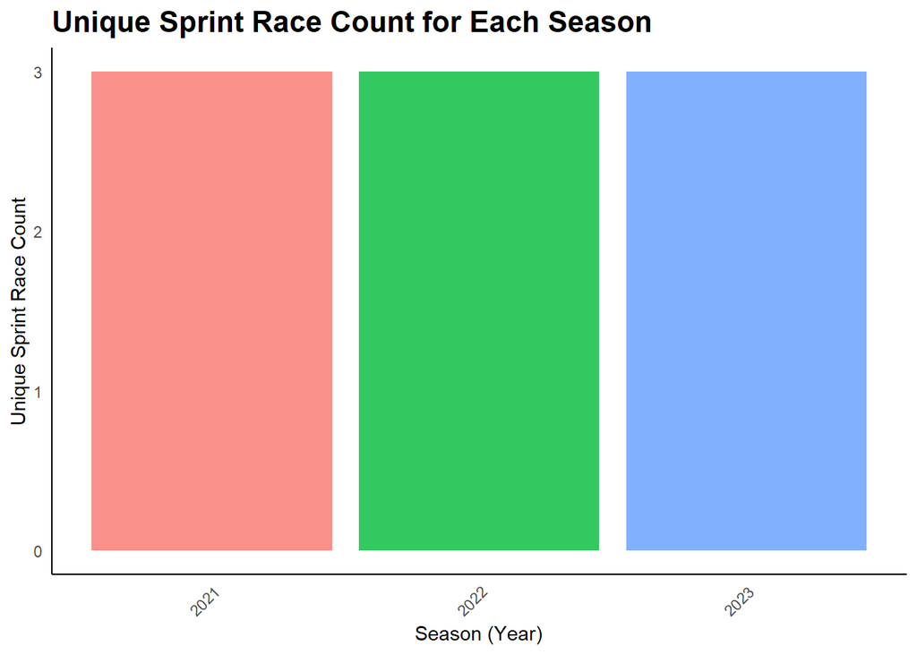

```r
# Count the number of unique raceId entries for each year
unique_sprint_count <- sprint_merged_data %>%
  group_by(year) %>%
  summarise(unique_sprint_count = n_distinct(raceId))

# Plot the results
ggplot(unique_sprint_count, aes(x = factor(year), y = unique_sprint_count, fill = factor(year))) +
  geom_bar(stat = "identity", alpha = 0.8) +
  labs(title = "Unique Sprint Race Count for Each Season",
       x = "Season (Year)",
       y = "Unique Sprint Race Count") +
  theme_minimal() +
  theme(axis.text.x = element_text(angle = 45, hjust = 1),
        plot.title = element_text(size = 16, face = "bold"),
        plot.caption = element_text(size = 10),
        panel.grid.major = element_blank(),
        panel.grid.minor = element_blank(),
        panel.border = element_blank(),
        axis.line = element_line(color = "black", size = 0.5),
        legend.position = "none")
```

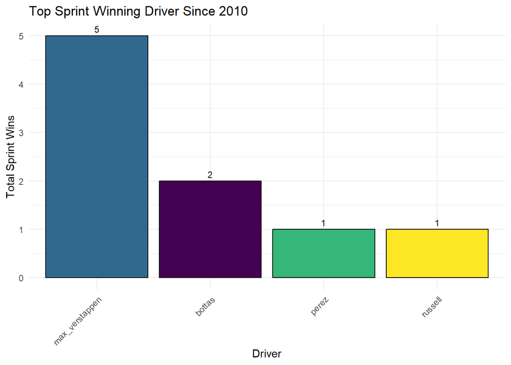

```r
# Summarize total wins for each driver
top_sprint_winning_drivers <- sprint_merged_data %>%
  filter(positionOrder == 1) %>%
  group_by(driverId) %>%
  summarize(total_sprint_wins = n())

# Merge with driver information
top_sprint_winning_drivers <- top_sprint_winning_drivers %>%
  inner_join(drivers_df, by = "driverId")

# Create a bar plot for the top winning driver
ggplot(top_sprint_winning_drivers, aes(x = reorder(driverRef, -total_sprint_wins), y = total_sprint_wins, fill = driverRef)) +
  geom_bar(stat = "identity", color = "black") +
  geom_text(aes(label = total_sprint_wins), vjust = -0.5, size = 3) +
  labs(title = "Top Sprint Winning Driver Since 2010",
       x = "Driver",
       y = "Total Sprint Wins") +
  scale_fill_viridis(discrete = TRUE, option = "D") +
  theme_minimal() +
  theme(axis.text.x = element_text(angle = 45, hjust = 1),
        legend.position = "none")
```

Max Verstappen dominated the sprint races, clinching the majority of victories with a total of 5, while Valtteri Bottas secured two wins. In close pursuit are Sergio Perez and George Russell, each notching one victory apiece.

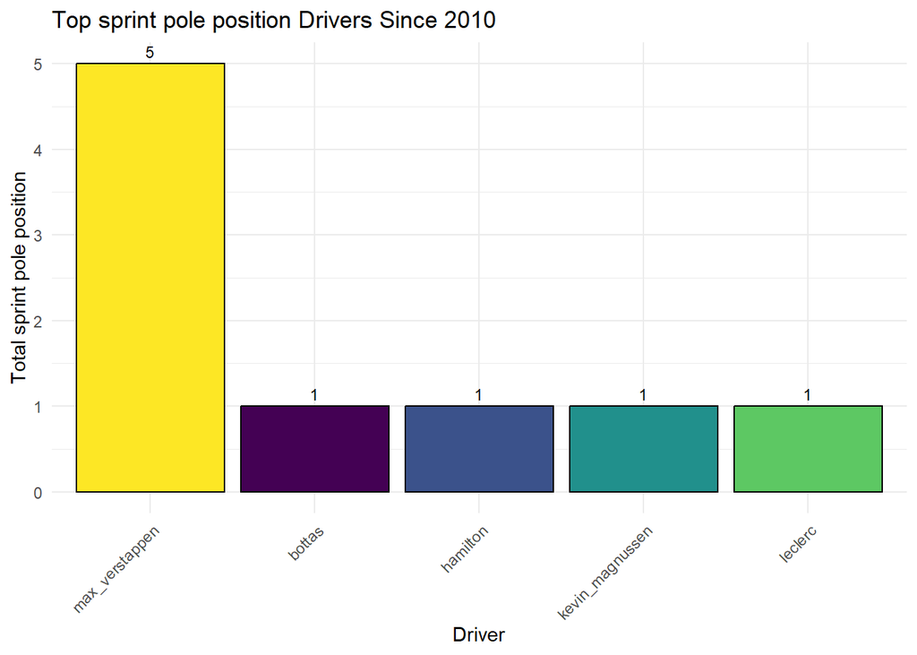

```r
# Summarize total pole position for each driver
top_sprint_poleposition_drivers <- sprint_merged_data %>%
  filter(grid == 1) %>%
  group_by(driverId) %>%
  summarize(total_sprint_poleposition = n())


# Merge with driver information
top_sprint_poleposition_drivers <- top_sprint_poleposition_drivers %>%
  inner_join(drivers_df, by = "driverId")


# Plot the results
ggplot(top_sprint_poleposition_drivers, aes(x = reorder(driverRef, -total_sprint_poleposition), y = total_sprint_poleposition, fill = driverRef)) +
  geom_bar(stat = "identity", color = "black") +
  geom_text(aes(label = total_sprint_poleposition), vjust = -0.5, size = 3) +
  labs(title = "Top sprint pole position Drivers Since 2010",
       x = "Driver",
       y = "Total sprint pole position") +
  scale_fill_viridis(discrete = TRUE, option = "D") +
  theme_minimal() +
  theme(axis.text.x = element_text(angle = 45, hjust = 1),
        legend.position = "none")
```

Max Verstappen showcased a commanding performance in sprint race pole positions, securing the majority of victories with a total of 5. Valtteri Bottas, Lewis Hamilton, Kevin Magnussen, and Charles Leclerc each secured one pole position apiece.

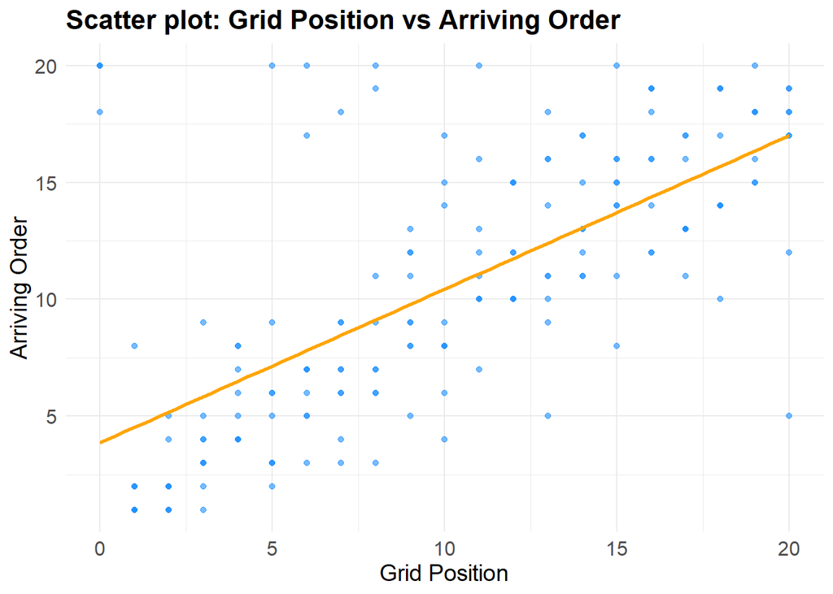

```r
# Scatter plot with regression line
ggplot(sprint_merged_data, aes(x = grid, y = positionOrder)) +
  geom_point(alpha = 0.6, color = "dodgerblue") +
  geom_smooth(method = "lm", se = FALSE, color = "orange") +
  labs(title = "Scatter plot: Grid Position vs Arriving Order",
       x = "Grid Position", y = "Arriving Order") +
  theme_minimal() +
  theme(plot.title = element_text(size = 16, face = "bold"),
        axis.text = element_text(size = 12),
        axis.title = element_text(size = 14),
        legend.position = "none")
```

The above plot shows the positive correlation between grid position and the Arriving order.

```r
# Create a binary variable indicating whether the pilot has won or not
sprint_merged_data$win <- ifelse(sprint_merged_data$positionOrder == 1, 1, 0)

# Logistic regression model
logistic_model_since_2010 <- glm(win ~ grid, data = sprint_merged_data, family = "binomial")

# Model summary
summary(logistic_model_since_2010)
```

```
##
## Call:
## glm(formula = win ~ grid, family = "binomial", data = sprint_merged_data)
##
## Coefficients:
##             Estimate Std. Error z value Pr(>|z|)
## (Intercept)   0.1634     0.6253   0.261  0.79389
## grid         -0.7674     0.2542  -3.018  0.00254 **
## ---
## Signif. codes:  0 '***' 0.001 '**' 0.01 '*' 0.05 '.' 0.1 ' ' 1
##
## (Dispersion parameter for binomial family taken to be 1)
##
##     Null deviance: 71.465  on 179  degrees of freedom
## Residual deviance: 40.500  on 178  degrees of freedom
## AIC: 44.5
##
## Number of Fisher Scoring iterations: 9
```

```r
# Use the fitted logistic regression model
logistic_model <- glm(win ~ grid, data = sprint_merged_data, family = "binomial")

# Create a dataframe with desired starting positions
grid_values <- data.frame(grid = 1:20)  # Adjust this range according to your needs

# Calculate estimated win probabilities for each starting position
predicted_probs <- predict(logistic_model, newdata = grid_values, type = "response")

# Combine starting positions and estimated win probabilities into a dataframe
predicted_data <- data.frame(grid = grid_values$grid, predicted_prob = predicted_probs)

# Print the resulting dataframe
print(predicted_data)
```

```
##    grid predicted_prob
## 1     1   3.534328e-01
## 2     2   2.024032e-01
## 3     3   1.053919e-01
## 4     4   5.185493e-02
## 5     5   2.476094e-02
## 6     6   1.164951e-02
## 7     7   5.442111e-03
## 8     8   2.533823e-03
## 9     9   1.177896e-03
## 10   10   5.471693e-04
## 11   11   2.540913e-04
## 12   12   1.179749e-04
## 13   13   5.477189e-05
## 14   14   2.542794e-05
## 15   15   1.180478e-05
## 16   16   5.480261e-06
## 17   17   2.544153e-06
## 18   18   1.181094e-06
## 19   19   5.483091e-07
## 20   20   2.545460e-07
```

```r
# Calculate the total number of races for each grid position
total_sprint_races_per_grid <- table(sprint_merged_data$grid)

# Calculate the number of wins for each grid position
sprint_wins_per_grid <- table(sprint_merged_data$grid[sprint_merged_data$positionOrder == 1])

# Ensure the vectors have the same length
all_sprint_grid_positions <- 1:max(as.numeric(names(total_sprint_races_per_grid)), as.numeric(names(sprint_wins_per_grid)))
total_sprint_races_per_grid <- total_sprint_races_per_grid[as.character(all_grid_positions)]
sprint_wins_per_grid <- sprint_wins_per_grid[as.character(all_grid_positions)]

# Calculate the winning percentage for each grid position
winning_percentage_per_grid <- sprint_wins_per_grid / total_sprint_races_per_grid * 100

# Create a data frame with grid position and winning percentage
ordered_results <- data.frame(grid_position = as.numeric(names(winning_percentage_per_grid)),
                              winning_percentage = winning_percentage_per_grid)

# Remove rows with NA values in winning_percentage
ordered_results <- na.omit(ordered_results)

# Drop the "winning_percentage.Var1" column
ordered_results <- subset(ordered_results, select = -c(winning_percentage.Var1))

# Order the results by winning percentage in descending order
ordered_results <- ordered_results[order(ordered_results$winning_percentage.Freq, decreasing = TRUE), ]

# Display the ordered results
cat("Grid positions ordered by winning percentage:\n")
```

```
## Grid positions ordered by winning percentage:
```

```r
print(ordered_results)
```

```
##   grid_position winning_percentage.Freq
## 1             1                55.55556
## 2             2                33.33333
## 3             3                11.11111
```

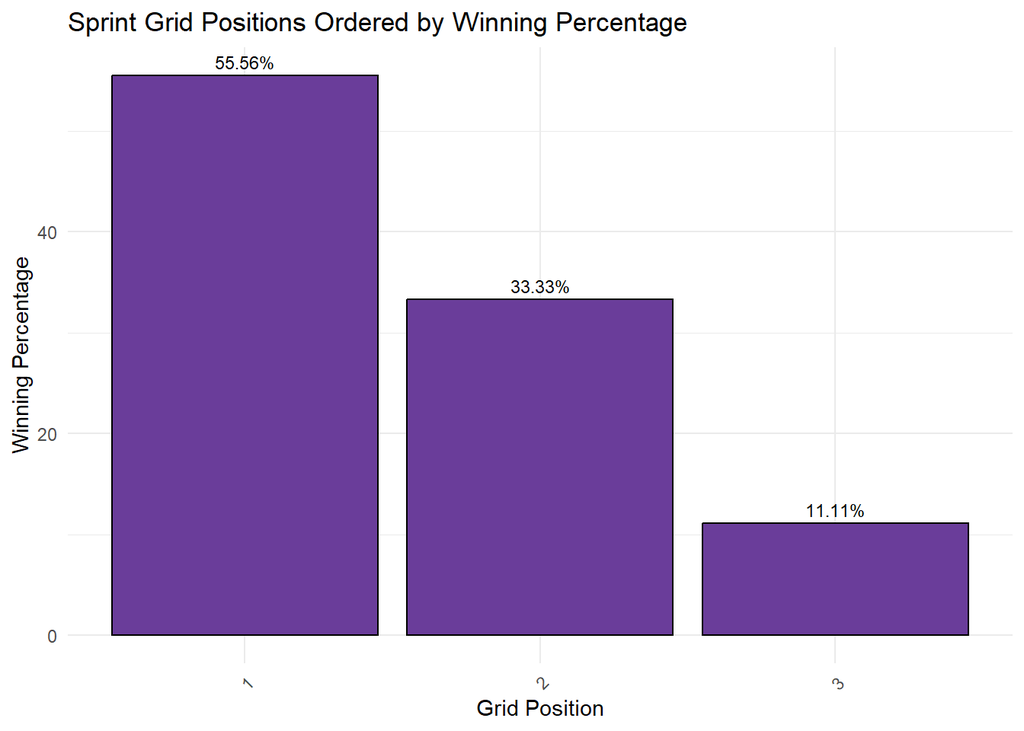

```r
ggplot(ordered_results, aes(x = reorder(factor(grid_position), -winning_percentage.Freq), y = winning_percentage.Freq)) +
  geom_bar(stat = "identity", fill = "#6a3d9a", color = "black") +  # Custom color
  labs(title = "Sprint Grid Positions Ordered by Winning Percentage",
       x = "Grid Position",
       y = "Winning Percentage") +
  theme_minimal() +
  theme(axis.text.x = element_text(angle = 45, hjust = 1)) +
  geom_text(aes(label = paste0(round(winning_percentage.Freq, 2), "%")), vjust = -0.5, size = 3) +  # Label with percentage
  scale_fill_manual(values = "#6a3d9a")  # Matching color for bars
```

The statistical breakdown of sprint race victories reveals that 55.56% were claimed by drivers starting from the first grid position, while the second and third grid positions accounted for 33.33% and 11.11% of the wins, respectively.

## 6. Conclusion

This study reinforces the presence of a positive correlation (0.5883153) between grid position and finishing order in Formula 1 races. While variations exist across seasons and circuits, the average correlation maintains a consistent pattern.

Specific circuits, like Autódromo Internacional do Algarve (0.8270677), exhibit a robust correlation, contrasting with others, such as Autodromo Enzo e Dino Ferrari (0.3714756), which demonstrate a weaker but consistently positive relationship.

Noteworthy is the examination of individual drivers, with Logan Sargeant showcasing the highest correlation (0.60299786), signaling an exceptional ability to convert favorable grid positions into race success. Conversely, some drivers display a slight negative correlation.

Regarding constructors, while an overall modest correlation with grid positions is observed, exceptions like the Williams team underscore the significant influence of team dynamics.

Exploring pit stop dynamics, a distinct trend emerges as winning drivers tend to make fewer pit stops, emphasizing their efficiency and strategic prowess during races.

Sprint races exhibit an even stronger correlation, likely influenced by their condensed format, leaving drivers with limited time for recovery from unfavorable starting positions.

A notable observation is the significance of a favorable grid position, with a substantial 87.9% of standard races won by drivers starting in the top 3 positions. In sprint races, this percentage rises to 100%, highlighting the critical importance of a favorable grid position in shorter-format competitions.

A curious trend emerges when examining the ratio between winning Grand Prix races and pole positions for the top 4 drivers. Sebastian Vettel, Lewis Hamilton, Nico Rosberg, and Max Verstappen all showcase varied ratios, shedding light on factors such as overtaking ability, car performance, circuit characteristics, and weather conditions. Particularly intriguing is Max Verstappen’s aggressive driving style and adept overtaking skills, evident in his high win count despite starting from the pole position less frequently.